# community_phenology

Jannet Vu

10/26/2022

Manuscript title: Temperature and rainfall seasonality drives tropical community phenology in southeastern Madagascar

**Goal is identify the association between regional weather patterns and community phenology (flowering & fruiting) Kianjavato at the monthly scale**

#### Set up working environment

First set up working environment and load in relevant files

```r
# load in packages
library(dplyr)
library(lubridate)
library(ggplot2)
library(reshape)
library(corrgram)
library(DescTools)
library(doParallel)
library(gridExtra)
library(caret)
library(cowplot)
library(AICcmodavg)
library(betareg)
library(ggeffects)

# detect cores for parallel computing
numcores <- detectCores() -1
registerDoParallel(numcores) # register cores

# list of month labels
mthname <- c("Jan","Feb","Mar","Apr","May","Jun","Jul","Aug","Sep","Oct","Nov","Dec")

# load appropriate files
# data for plant vernacular and Latin names
plant_names <- read.csv('phen_plantnames.csv',
                        header= T,
                        stringsAsFactors = F) # local plant and Latin names

# dataset for climatic association analysis
kphen_pop_fr <- read.csv('kian_phen_pop_fruit_clim.csv',
                         header= T,
                         stringsAsFactors = F)[,-1]

kphen_pop_fr$Date <- as.Date(kphen_pop_fr$Date,
                             tz = 'Africa/Nairobi')

kphen_pop_fl <- read.csv('kian_phen_pop_flower_clim.csv',
                         header= T,
                         stringsAsFactors = F)[,-1]

kphen_pop_fl$Date <- as.Date(kphen_pop_fl$Date,
                             tz = 'Africa/Nairobi')
```

columns:  
year - year  
month - month  
monthname - categorical month name  
Date - date  
dataset - indicate forest, sssw = Sangasanga and vvsw = Vatovavy  
n - total indiviudals sampled in a given month np - maximum community level productivity in a given month ns - total taxa sampled in a given month individual_count - number of individuals flowering or fruiting  
sprich_count - species richness of flowering or fruiting  
productivity_sum - fruiting or flowering productivity (sum of phenology across individuals)  
individuals - proportion of individuals flowering or fruiting  
sprich - proportion of taxa flowering or fruiting  
productivity - relative fruiting or flowering productivity (sum of phenology across individuals/maximal potential phenology across all individuals)  
rain - cumulative monthly rain (mm)  
temp - average monthly temp (C)  
rad - cumulative monthly solar radiation $(Wm^-2)$  
onset - 0/1 indicates if the record occurs at the onset of the wet season (November -January) transition - 0/1 indicates if the record occurs at the transition between the dry and wet season (October-December)

```r
# visualize to get sense of data
head(kphen_pop_fr)
```

```
##   year month monthname       Date dataset   n  np ns individual_count
## 1 2010     7       Jul 2010-07-01    sssw 102 408 37               25
## 2 2010     7       Jul 2010-07-01    vvsw  93 372 38                8
## 3 2010     8       Aug 2010-08-01    sssw 102 408 37               35
## 4 2010     8       Aug 2010-08-01    vvsw  93 372 38                9
## 5 2010     9       Sep 2010-09-01    sssw 102 408 37               27
## 6 2010     9       Sep 2010-09-01    vvsw  93 372 38               12
##   sprich_count productivity_sum individuals    sprich productivity  rain
## 1           15             37.0  0.24509804 0.4054054   0.09068627 153.0
## 2            5             10.0  0.08602151 0.1315789   0.02688172 153.0
## 3           18             39.0  0.34313725 0.4864865   0.09558824  74.4
## 4            6             10.0  0.09677419 0.1578947   0.02688172  74.4
## 5           16             37.5  0.26470588 0.4324324   0.09191176  36.4
## 6            9             11.5  0.12903226 0.2368421   0.03091398  36.4
##       temp    rad onset transition
## 1 17.65867 102023     0          0
## 2 17.65867 102023     0          0
## 3 18.09977 118856     0          0
## 4 18.09977 118856     0          0
## 5 20.12969 159163     0          0
## 6 20.12969 159163     0          0
```

#### Visualize

Get distribution of the responses

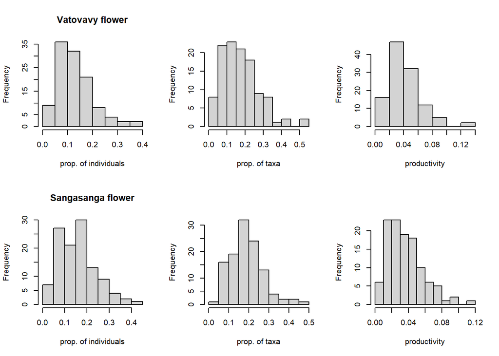

```r
par(mfrow = c(2,3))
hist(kphen_pop_fl$individuals[which(kphen_pop_fl$dataset == 'vvsw')],
     xlab ='prop. of individuals',
     main = 'Vatovavy flower')

hist(kphen_pop_fl$sprich[which(kphen_pop_fl$dataset == 'vvsw')],
     xlab = 'prop. of taxa',
     main = '')

hist(kphen_pop_fl$productivity[which(kphen_pop_fl$dataset == 'vvsw')],
     xlab ='productivity',
     main = '')

hist(kphen_pop_fl$individuals[which(kphen_pop_fl$dataset == 'sssw')],
     xlab ='prop. of individuals',
     main = 'Sangasanga flower')

hist(kphen_pop_fl$sprich[which(kphen_pop_fl$dataset == 'sssw')],
     xlab = 'prop. of taxa',
     main = '')

hist(kphen_pop_fl$productivity[which(kphen_pop_fl$dataset == 'sssw')],
     xlab ='productivity',
     main = '')
```

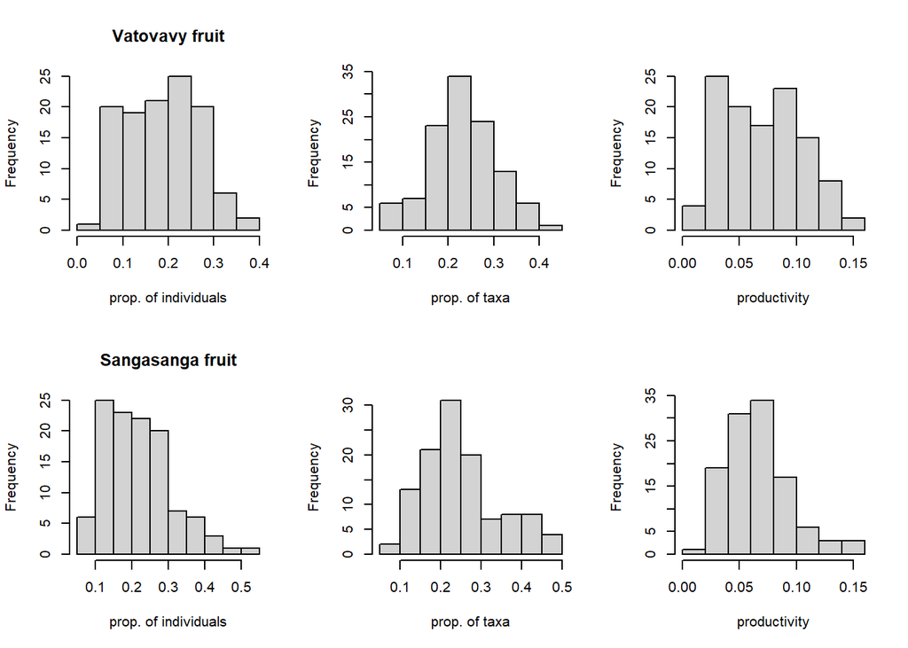

```r
par(mfrow = c(2,3))
hist(kphen_pop_fr$individuals[which(kphen_pop_fr$dataset == 'vvsw')],
     xlab ='prop. of individuals',
     main = 'Vatovavy fruit')

hist(kphen_pop_fr$sprich[which(kphen_pop_fr$dataset == 'vvsw')],
     xlab = 'prop. of taxa',
     main = '')

hist(kphen_pop_fr$productivity[which(kphen_pop_fr$dataset == 'vvsw')],
     xlab ='productivity',
     main = '')

hist(kphen_pop_fr$individuals[which(kphen_pop_fr$dataset == 'sssw')],
     xlab ='prop. of individuals',
     main = 'Sangasanga fruit')

hist(kphen_pop_fr$sprich[which(kphen_pop_fr$dataset == 'sssw')],
     xlab = 'prop. of taxa',
     main = '')

hist(kphen_pop_fr$productivity[which(kphen_pop_fr$dataset == 'sssw')],
     xlab ='productivity',
     main = '')
```

Evaluate the relationship between weather metrics

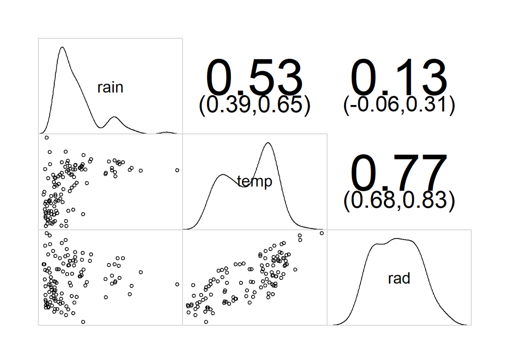

```r
# examine the correlation plots between the independent variables
# Only need to evaluate for community and phenology since same regional data used for both phenology stages and communities
# local weather data was unavailable for study period
corrgram(kphen_pop_fl[which(kphen_pop_fl$dataset=='vvsw'),c('rain','temp','rad')],
         lower.panel =panel.pts,
         upper.panel= panel.conf,
         diag.panel = panel.density)
```

Temperature and solar radiation are highly correlation, therefore should not be put into the same model.

Visualize community phenology across months for flowering

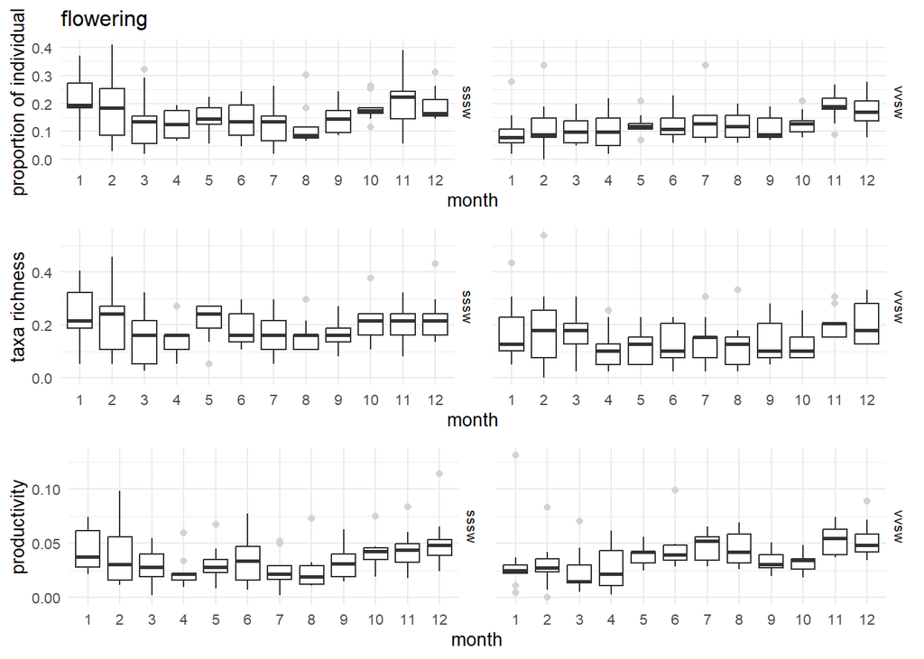

```r
# generate boxplot of prop of individuals flowering across months
fli_box <- ggplot(kphen_pop_fl %>% filter(year != 2010), # drop 2010 since initial data collection period can be associated with inconsistent sampling procedures
                  aes(x=as.factor(month),y=individuals)) +
                geom_boxplot(outlier.colour="lightgrey") +
                theme_minimal(base_size=10) +
                theme(legend.position = 'none') +
                labs(x = 'month',
                     y ='proportion of individual',
                     title = 'flowering') +
                facet_wrap(~dataset,
                           nrow = 1,
                           ncol = 2,
                           strip.position = 'right')

# generate boxplot of prop of taxa flowering across months
flsp_box <- ggplot(kphen_pop_fl %>% filter(year != 2010),
                   aes(x=as.factor(month),y=sprich))+
                geom_boxplot(outlier.colour="lightgrey")+
                theme_minimal(base_size=10) +
                theme(legend.position = 'none') +
                labs(x = 'month',y ='taxa richness') +
                facet_wrap(~dataset,
                           nrow = 1,
                           ncol = 2,
                           strip.position = 'right')

# generate boxplot of flowering productivity across months
flprod_box <- ggplot(kphen_pop_fl %>% filter(year != 2010),
                     aes(x=as.factor(month),y=productivity))+
                  geom_boxplot(outlier.colour="lightgrey")+
                  theme_minimal(base_size=10) +
                  theme(legend.position = 'none') +
                  labs(x = 'month',y ='productivity') +
                  facet_wrap(~dataset,
                             nrow = 1,
                             ncol = 2,
                             strip.position = 'right')

plot_grid(fli_box, flsp_box, flprod_box, nrow = 3, ncol=1)
```

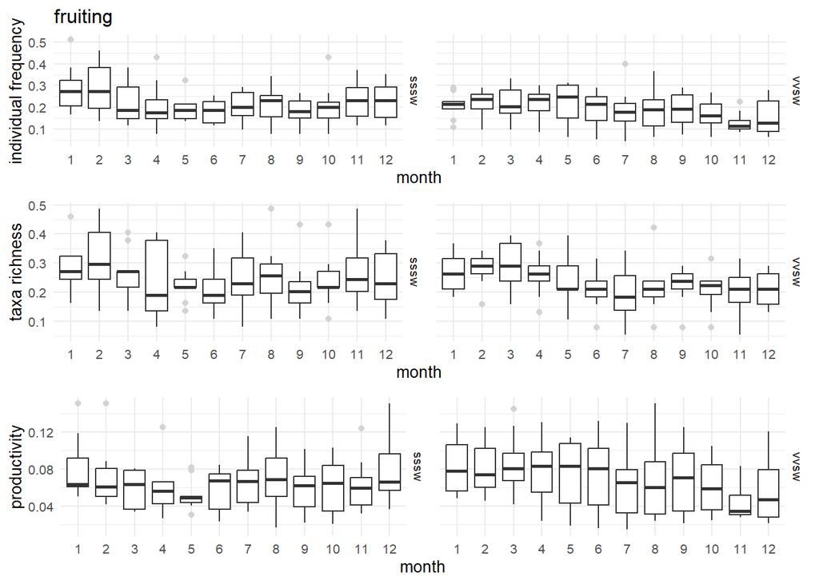

```r
# generate boxplot of prop of individuals fruiting across months
fri_box  <- ggplot(kphen_pop_fr,
                   aes(x=as.factor(month),y=individuals)) +
                geom_boxplot(outlier.colour="lightgrey") +
                theme_minimal(base_size=10) +
                theme(legend.position = 'none') +
                labs(x = 'month',y ='individual frequency', title = 'fruiting') +
                scale_fill_manual(values = c('grey80','grey40')) +
                facet_wrap(~dataset,
                           nrow = 1,
                           ncol = 2,
                           strip.position = 'right')

# generate boxplot of prop of taxa fruiting across months
frsp_box <- ggplot(kphen_pop_fr,
                   aes(x=as.factor(month),y=sprich))+
                geom_boxplot(outlier.colour="lightgrey")+
                theme_minimal(base_size=10) +
                theme(legend.position = 'none') +
                labs(x = 'month',y ='taxa richness') +
                facet_wrap(~dataset,
                           nrow = 1,
                           ncol = 2,
                           strip.position = 'right')

frprod_box  <- ggplot(kphen_pop_fr,
                      aes(x=as.factor(month),y=productivity)) +
                  geom_boxplot(outlier.colour="lightgrey")+
                  theme_minimal(base_size=10) +
                  theme(legend.position = 'none') +
                  labs(x = 'month',y ='productivity') +
                  facet_wrap(~dataset,
                             nrow = 1,
                             ncol = 2,
                             strip.position = 'right')

plot_grid(fri_box, frsp_box, frprod_box, nrow = 3, ncol=1)
```

Visualize community phenology across years for flowering

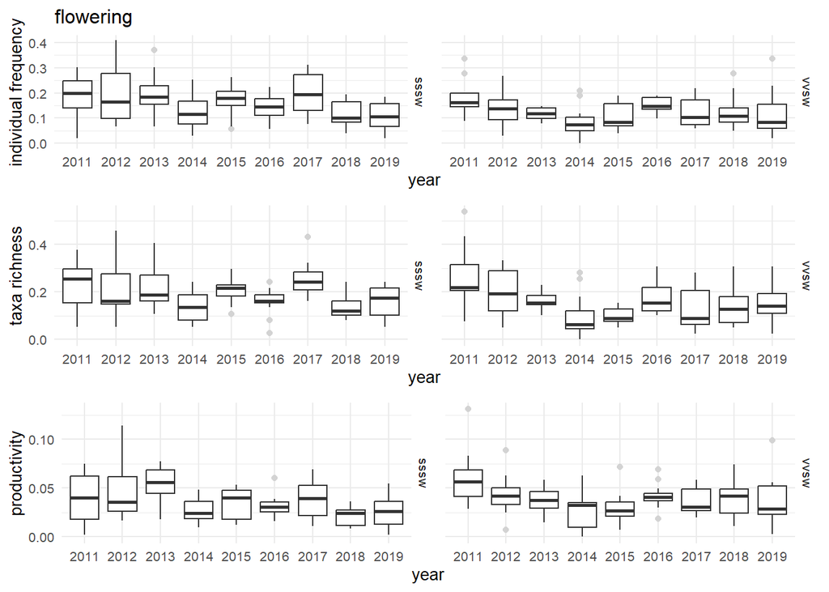

```r
# generate boxplot of prop of individuals flowering across years
fli_box <- ggplot(kphen_pop_fl %>% filter(year != 2010),
                  aes(x=as.factor(year),y=individuals))+
                geom_boxplot(outlier.colour="lightgrey")+
                theme_minimal(base_size=10) +
                labs(x = 'year',
                     y ='individual frequency',
                     title = 'flowering')+
                theme(legend.position = 'none')  +
                facet_wrap(~dataset,
                           nrow = 1,
                           ncol = 2,
                           strip.position = 'right')

# generate boxplot of prop of taxa flowering across years
flsp_box <- ggplot(kphen_pop_fl %>% filter(year != 2010),
                   aes(x=as.factor(year),y=sprich))+
                geom_boxplot(outlier.colour="lightgrey")+
                theme_minimal(base_size=10) +
                labs(x = 'year',
                     y ='taxa richness')+
                theme(legend.position = 'none')  +
                facet_wrap(~dataset,
                           nrow = 1,
                           ncol = 2,
                           strip.position = 'right')

# generate boxplot of flower productivity across years
flprod_box <- ggplot(kphen_pop_fl %>% filter(year != 2010),
                     aes(x=as.factor(year),y=productivity))+
                  geom_boxplot(outlier.colour="lightgrey")+
                  theme_minimal(base_size=10) +
                  labs(x = 'year',
                       y ='productivity')+
                  theme(legend.position = 'none')  +
                  facet_wrap(~dataset,
                             nrow = 1,
                             ncol = 2,
                             strip.position = 'right')

plot_grid(fli_box, flsp_box,flprod_box, nrow = 3, ncol=1)
```

Visualize community phenology across years for fruiting

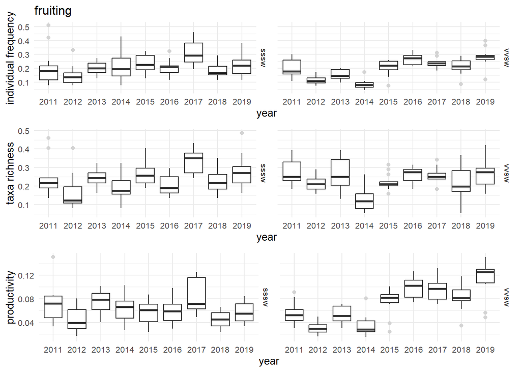

```r
# generate boxplot of prop of individual fruiting across years
fri_box <- ggplot(kphen_pop_fr %>% filter(year != 2010),
                  aes(x=as.factor(year),y=individuals)) +
              geom_boxplot(outlier.colour="lightgrey") +
              theme_minimal(base_size=10) +
              labs(x = 'year',
                   y ='individual frequency',
                   title = 'fruiting') +
              theme(legend.position = 'none')  +
              facet_wrap(~dataset,
                         nrow = 1,
                         ncol = 2,
                         strip.position = 'right')

# generate boxplot of prop of taxa fruiting across years
frsp_box <- ggplot(kphen_pop_fr %>% filter(year != 2010),
                   aes(x=as.factor(year),y=sprich)) +
              geom_boxplot(outlier.colour="lightgrey")+
              theme_minimal(base_size=10) +
              labs(x = 'year',
                   y ='taxa richness')+
              theme(legend.position = 'none')  +
              facet_wrap(~dataset,
                         nrow = 1,
                         ncol = 2,
                         strip.position = 'right')

# generate boxplot of fruit productivity across years
frprod_box <- ggplot(kphen_pop_fr %>% filter(year != 2010),
                     aes(x=as.factor(year),y=productivity))+
                  geom_boxplot(outlier.colour="lightgrey") +
                  theme_minimal(base_size=10) +
                  labs(x = 'year',
                       y ='productivity') +
                  theme(legend.position = 'none') +
                  facet_wrap(~dataset,
                             nrow = 1,
                             ncol = 2,
                             strip.position = 'right')

plot_grid(fri_box, frsp_box, frprod_box, nrow = 3, ncol=1)
```

Visualize phenology as time series across dates

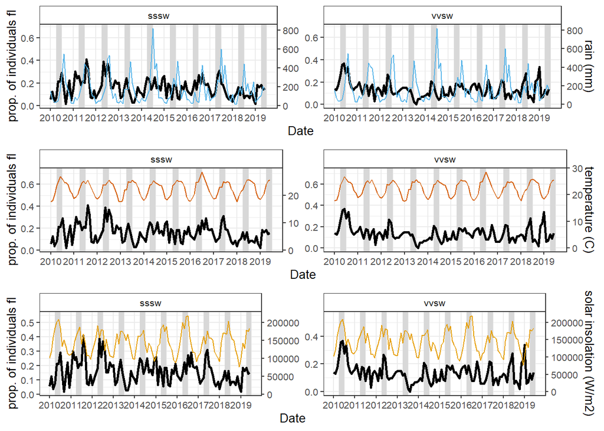

```r
# plot time series of prop flowering individuals
base_iplot <- ggplot(kphen_pop_fl,
                     aes(x = Date, y = individuals)) +
                geom_line(size = 1) +
                geom_rect(aes(xmin = as.Date('2010-10-01'), xmax = as.Date('2010-12-31'),
                      ymin = -Inf, ymax = Inf), alpha = 0.005) +
                geom_rect(aes(xmin = as.Date('2011-10-01'), xmax = as.Date('2011-12-31'),
                      ymin = -Inf, ymax = Inf), alpha = 0.005) +
                geom_rect(aes(xmin = as.Date('2012-10-01'), xmax = as.Date('2012-12-31'),
                      ymin = -Inf, ymax = Inf),  alpha = 0.005) +
                geom_rect(aes(xmin = as.Date('2013-10-01'), xmax = as.Date('2013-12-31'),
                      ymin = -Inf, ymax = Inf),  alpha = 0.005) +
                geom_rect(aes(xmin = as.Date('2014-10-01'), xmax = as.Date('2014-12-31'),
                      ymin = -Inf, ymax = Inf),  alpha = 0.005) +
                geom_rect(aes(xmin = as.Date('2015-10-01'), xmax = as.Date('2015-12-31'),
                      ymin = -Inf, ymax = Inf),  alpha = 0.005) +
                geom_rect(aes(xmin = as.Date('2016-10-01'), xmax = as.Date('2016-12-31'),
                      ymin = -Inf, ymax = Inf),  alpha = 0.005) +
                geom_rect(aes(xmin = as.Date('2017-10-01'), xmax = as.Date('2017-12-31'),
                      ymin = -Inf, ymax = Inf),  alpha = 0.005) +
                geom_rect(aes(xmin = as.Date('2018-10-01'), xmax = as.Date('2018-12-31'),
                      ymin = -Inf, ymax = Inf), alpha = 0.005) +
                geom_rect(aes(xmin = as.Date('2019-10-01'), xmax = as.Date('2019-12-31'),
                      ymin = -Inf, ymax = Inf),  alpha = 0.005) +
                scale_x_date(breaks = function(x) seq.Date(from = as.Date('2010-07-01'),
                                                           to = as.Date('2019-12-31'),
                                                           by = "1 year"),
                             date_labels = "%Y") +
                theme_bw(base_size=10) +
                theme(strip.background = element_rect('white')) +
                facet_wrap(~dataset,
                           ncol=2,
                           strip.position = 'top',
                           scales = 'free_y')

# get rain plot
rain_plot <- base_iplot +
              geom_line(aes(x = Date, y =rain/1200),
                        linetype = 'solid',
                        colour = '#56B4E9',
                        linewidth = 0.5) +
              scale_y_continuous(sec.axis = sec_axis(~.*1200, name = 'rain (mm)'),
                                 name = 'prop. of individuals fl')

temp_plot <- base_iplot +
              geom_line(aes(x = Date, y =temp/40),
                        linetype = 'solid',
                        colour = '#D55E00',
                        linewidth = 0.5) +
              scale_y_continuous(sec.axis = sec_axis(~.*40, name = 'temperature (C)'),
                                 name = 'prop. of individuals fl')

rad_plot <- base_iplot +
              geom_line(aes(x = Date, y = rad/400000),
                        linetype = 'solid',
                        colour = '#E69F00',
                        linewidth = 0.5) +
              scale_y_continuous(sec.axis = sec_axis(~.*400000, name = 'solar insolation (W/m2)'),
                                 name = 'prop. of individuals fl')


# arrange figure and output
plot_grid(rain_plot, temp_plot, rad_plot, nrow = 3, ncol=1)
```

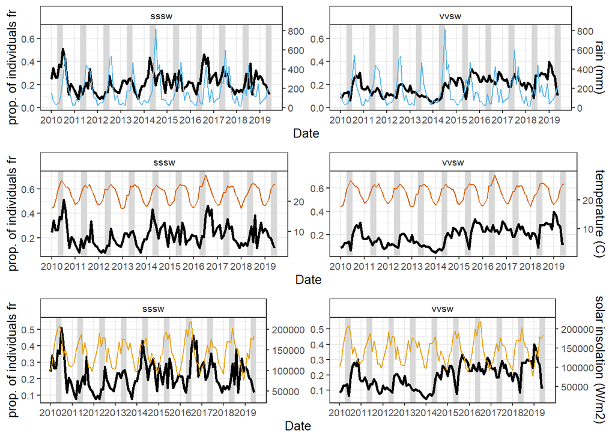

```r
# plot time series of prop fruiting individuals
base_iplot <- ggplot(kphen_pop_fr, aes(x = Date, y = individuals)) +
                geom_line(size = 1) +
                geom_rect(aes(xmin = as.Date('2010-10-01'), xmax = as.Date('2010-12-31'),
                      ymin = -Inf, ymax = Inf), alpha = 0.005) +
                geom_rect(aes(xmin = as.Date('2011-10-01'), xmax = as.Date('2011-12-31'),
                      ymin = -Inf, ymax = Inf), alpha = 0.005) +
                geom_rect(aes(xmin = as.Date('2012-10-01'), xmax = as.Date('2012-12-31'),
                      ymin = -Inf, ymax = Inf),  alpha = 0.005) +
                geom_rect(aes(xmin = as.Date('2013-10-01'), xmax = as.Date('2013-12-31'),
                      ymin = -Inf, ymax = Inf),  alpha = 0.005) +
                geom_rect(aes(xmin = as.Date('2014-10-01'), xmax = as.Date('2014-12-31'),
                      ymin = -Inf, ymax = Inf),  alpha = 0.005) +
                geom_rect(aes(xmin = as.Date('2015-10-01'), xmax = as.Date('2015-12-31'),
                      ymin = -Inf, ymax = Inf),  alpha = 0.005) +
                geom_rect(aes(xmin = as.Date('2016-10-01'), xmax = as.Date('2016-12-31'),
                      ymin = -Inf, ymax = Inf),  alpha = 0.005) +
                geom_rect(aes(xmin = as.Date('2017-10-01'), xmax = as.Date('2017-12-31'),
                      ymin = -Inf, ymax = Inf),  alpha = 0.005) +
                geom_rect(aes(xmin = as.Date('2018-10-01'), xmax = as.Date('2018-12-31'),
                      ymin = -Inf, ymax = Inf), alpha = 0.005) +
                geom_rect(aes(xmin = as.Date('2019-10-01'), xmax = as.Date('2019-12-31'),
                      ymin = -Inf, ymax = Inf),  alpha = 0.005) +
                scale_x_date(breaks = function(x) seq.Date(from = as.Date('2010-07-01'),
                                                           to = as.Date('2019-12-31'),
                                                           by = "1 year"),
                             date_labels = "%Y") +
                theme_bw(base_size=10) +
                theme(strip.background = element_rect('white')) +
                facet_wrap(~dataset,
                           ncol=2,
                           strip.position = 'top',
                           scales = 'free_y')

# get rain plot
rain_plot <- base_iplot +
              geom_line(aes(x = Date, y =rain/1200),
                        linetype = 'solid',
                        colour = '#56B4E9',
                        linewidth = 0.5) +
              scale_y_continuous(sec.axis = sec_axis(~.*1200, name = 'rain (mm)'),
                                 name = 'prop. of individuals fr')

temp_plot <- base_iplot +
              geom_line(aes(x = Date, y =temp/40),
                        linetype = 'solid',
                        colour = '#D55E00',
                        linewidth = 0.5) +
              scale_y_continuous(sec.axis = sec_axis(~.*40, name = 'temperature (C)'),
                                 name = 'prop. of individuals fr')

rad_plot <- base_iplot +
              geom_line(aes(x = Date, y = rad/400000),
                        linetype = 'solid',
                        colour = '#E69F00',
                        linewidth = 0.5) +
              scale_y_continuous(sec.axis = sec_axis(~.*400000, name = 'solar insolation (W/m2)'),
                                 name = 'prop. of individuals fr')


# arrange figure and output
plot_grid(rain_plot, temp_plot, rad_plot, nrow = 3, ncol=1)
```

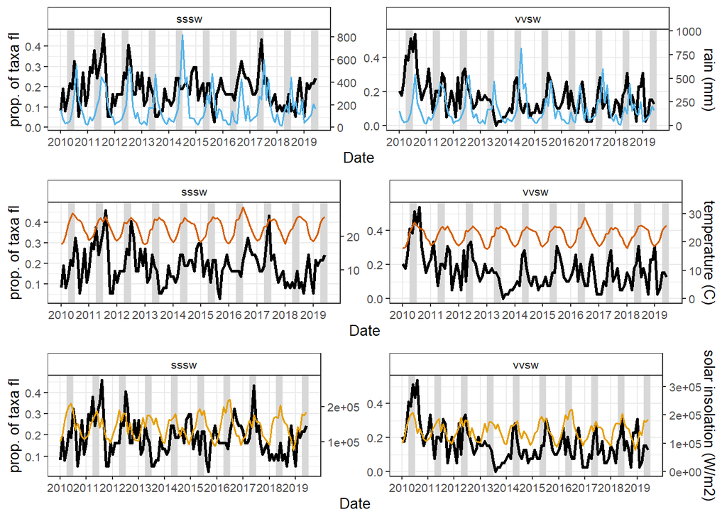

```r
# plot time series of prop flowering taxa
base_iplot <- ggplot(kphen_pop_fl,
                     aes(x = Date, y = sprich)) +
                geom_line(size = 1) +
                geom_rect(aes(xmin = as.Date('2010-10-01'), xmax = as.Date('2010-12-31'),
                      ymin = -Inf, ymax = Inf), alpha = 0.005) +
                geom_rect(aes(xmin = as.Date('2011-10-01'), xmax = as.Date('2011-12-31'),
                      ymin = -Inf, ymax = Inf), alpha = 0.005) +
                geom_rect(aes(xmin = as.Date('2012-10-01'), xmax = as.Date('2012-12-31'),
                      ymin = -Inf, ymax = Inf),  alpha = 0.005) +
                geom_rect(aes(xmin = as.Date('2013-10-01'), xmax = as.Date('2013-12-31'),
                      ymin = -Inf, ymax = Inf),  alpha = 0.005) +
                geom_rect(aes(xmin = as.Date('2014-10-01'), xmax = as.Date('2014-12-31'),
                      ymin = -Inf, ymax = Inf),  alpha = 0.005) +
                geom_rect(aes(xmin = as.Date('2015-10-01'), xmax = as.Date('2015-12-31'),
                      ymin = -Inf, ymax = Inf),  alpha = 0.005) +
                geom_rect(aes(xmin = as.Date('2016-10-01'), xmax = as.Date('2016-12-31'),
                      ymin = -Inf, ymax = Inf),  alpha = 0.005) +
                geom_rect(aes(xmin = as.Date('2017-10-01'), xmax = as.Date('2017-12-31'),
                      ymin = -Inf, ymax = Inf),  alpha = 0.005) +
                geom_rect(aes(xmin = as.Date('2018-10-01'), xmax = as.Date('2018-12-31'),
                      ymin = -Inf, ymax = Inf), alpha = 0.005) +
                geom_rect(aes(xmin = as.Date('2019-10-01'), xmax = as.Date('2019-12-31'),
                      ymin = -Inf, ymax = Inf),  alpha = 0.005) +
                scale_x_date(breaks = function(x) seq.Date(from = as.Date('2010-07-01'),
                                                           to = as.Date('2019-12-31'),
                                                           by = "1 year"),
                             date_labels = "%Y") +
                theme_bw(base_size=10) +
                theme(strip.background = element_rect('white')) +
                facet_wrap(~dataset,
                           ncol=2,
                           strip.position = 'top',
                           scales = 'free_y')

# get rain plot
rain_plot <- base_iplot +
               geom_line(aes(x = Date, y =rain/1800),
                          linetype = 'solid',
                          colour = '#56B4E9',
                          linewidth = 0.7) +
                scale_y_continuous(sec.axis = sec_axis(~.*1800, name = 'rain (mm)'),
                                   name = 'prop. of taxa fl')

temp_plot <- base_iplot +
               geom_line(aes(x = Date, y =temp/60),
                          linetype = 'solid',
                          colour = '#D55E00',
                          linewidth = 0.7) +
              scale_y_continuous(sec.axis = sec_axis(~.*60, name = 'temperature (C)'),
                                 name = 'prop. of taxa fl')

rad_plot <- base_iplot +
              geom_line(aes(x = Date, y = rad/600000),
                          linetype = 'solid',
                          colour = '#E69F00',
                          linewidth = 0.7) +
              scale_y_continuous(sec.axis = sec_axis(~.*600000, name = 'solar insolation (W/m2)'),
                                 name = 'prop. of taxa fl')


# arrange figure and output
plot_grid(rain_plot, temp_plot, rad_plot, nrow = 3, ncol=1)
```

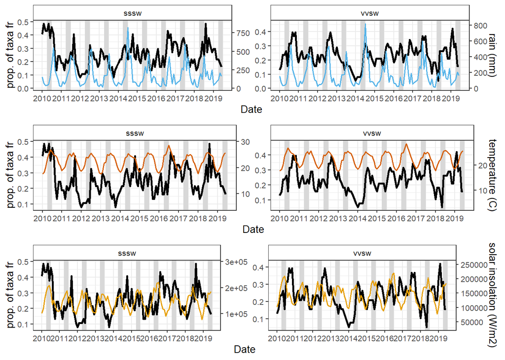

```r
# plot time series of prop fruiting taxa
base_iplot <- ggplot(kphen_pop_fr,
                     aes(x = Date, y = sprich)) +
                geom_line(size = 1) +
                geom_rect(aes(xmin = as.Date('2010-10-01'), xmax = as.Date('2010-12-31'),
                      ymin = -Inf, ymax = Inf), alpha = 0.005) +
                geom_rect(aes(xmin = as.Date('2011-10-01'), xmax = as.Date('2011-12-31'),
                      ymin = -Inf, ymax = Inf), alpha = 0.005) +
                geom_rect(aes(xmin = as.Date('2012-10-01'), xmax = as.Date('2012-12-31'),
                      ymin = -Inf, ymax = Inf),  alpha = 0.005) +
                geom_rect(aes(xmin = as.Date('2013-10-01'), xmax = as.Date('2013-12-31'),
                      ymin = -Inf, ymax = Inf),  alpha = 0.005) +
                geom_rect(aes(xmin = as.Date('2014-10-01'), xmax = as.Date('2014-12-31'),
                      ymin = -Inf, ymax = Inf),  alpha = 0.005) +
                geom_rect(aes(xmin = as.Date('2015-10-01'), xmax = as.Date('2015-12-31'),
                      ymin = -Inf, ymax = Inf),  alpha = 0.005) +
                geom_rect(aes(xmin = as.Date('2016-10-01'), xmax = as.Date('2016-12-31'),
                      ymin = -Inf, ymax = Inf),  alpha = 0.005) +
                geom_rect(aes(xmin = as.Date('2017-10-01'), xmax = as.Date('2017-12-31'),
                      ymin = -Inf, ymax = Inf),  alpha = 0.005) +
                geom_rect(aes(xmin = as.Date('2018-10-01'), xmax = as.Date('2018-12-31'),
                      ymin = -Inf, ymax = Inf), alpha = 0.005) +
                geom_rect(aes(xmin = as.Date('2019-10-01'), xmax = as.Date('2019-12-31'),
                      ymin = -Inf, ymax = Inf),  alpha = 0.005) +
                scale_x_date(breaks = function(x) seq.Date(from = as.Date('2010-07-01'),
                                                           to = as.Date('2019-12-31'),
                                                           by = "1 year"),
                             date_labels = "%Y") +
                theme_bw(base_size=10) +
                theme(strip.background = element_rect('white')) +
                facet_wrap(~dataset,
                           ncol=2,
                           strip.position = 'top',
                           scales = 'free_y')

# get rain plot
rain_plot <- base_iplot +
               geom_line(aes(x = Date, y =rain/1800),
                          linetype = 'solid',
                          colour = '#56B4E9',
                          linewidth = 0.7) +
                scale_y_continuous(sec.axis = sec_axis(~.*1800, name = 'rain (mm)'),
                                   name = 'prop. of taxa fr')

temp_plot <- base_iplot +
               geom_line(aes(x = Date, y =temp/60),
                          linetype = 'solid',
                          colour = '#D55E00',
                          linewidth = 0.7) +
              scale_y_continuous(sec.axis = sec_axis(~.*60, name = 'temperature (C)'),
                                 name = 'prop. of taxa fr')

rad_plot <- base_iplot +
              geom_line(aes(x = Date, y = rad/600000),
                          linetype = 'solid',
                          colour = '#E69F00',
                          linewidth = 0.7) +
              scale_y_continuous(sec.axis = sec_axis(~.*600000, name = 'solar insolation (W/m2)'),
                                 name = 'prop. of taxa fr')


# arrange figure and output
plot_grid(rain_plot, temp_plot, rad_plot, nrow = 3, ncol=1)
```

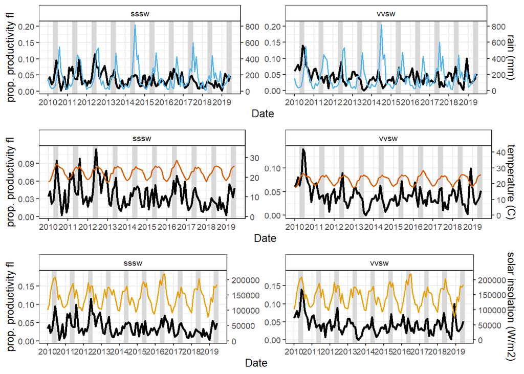

```r
# plot time series of proportional flowering productivity
base_iplot <- ggplot(kphen_pop_fl,
                     aes(x = Date, y = productivity)) +
                geom_line(size = 1) +
                geom_rect(aes(xmin = as.Date('2010-10-01'), xmax = as.Date('2010-12-31'),
                      ymin = -Inf, ymax = Inf), alpha = 0.005) +
                geom_rect(aes(xmin = as.Date('2011-10-01'), xmax = as.Date('2011-12-31'),
                      ymin = -Inf, ymax = Inf), alpha = 0.005) +
                geom_rect(aes(xmin = as.Date('2012-10-01'), xmax = as.Date('2012-12-31'),
                      ymin = -Inf, ymax = Inf),  alpha = 0.005) +
                geom_rect(aes(xmin = as.Date('2013-10-01'), xmax = as.Date('2013-12-31'),
                      ymin = -Inf, ymax = Inf),  alpha = 0.005) +
                geom_rect(aes(xmin = as.Date('2014-10-01'), xmax = as.Date('2014-12-31'),
                      ymin = -Inf, ymax = Inf),  alpha = 0.005) +
                geom_rect(aes(xmin = as.Date('2015-10-01'), xmax = as.Date('2015-12-31'),
                      ymin = -Inf, ymax = Inf),  alpha = 0.005) +
                geom_rect(aes(xmin = as.Date('2016-10-01'), xmax = as.Date('2016-12-31'),
                      ymin = -Inf, ymax = Inf),  alpha = 0.005) +
                geom_rect(aes(xmin = as.Date('2017-10-01'), xmax = as.Date('2017-12-31'),
                      ymin = -Inf, ymax = Inf),  alpha = 0.005) +
                geom_rect(aes(xmin = as.Date('2018-10-01'), xmax = as.Date('2018-12-31'),
                      ymin = -Inf, ymax = Inf), alpha = 0.005) +
                geom_rect(aes(xmin = as.Date('2019-10-01'), xmax = as.Date('2019-12-31'),
                      ymin = -Inf, ymax = Inf),  alpha = 0.005) +
                scale_x_date(breaks = function(x) seq.Date(from = as.Date('2010-07-01'),
                                                           to = as.Date('2019-12-31'),
                                                           by = "1 year"),
                             date_labels = "%Y") +
                theme_bw(base_size=10) +
                theme(strip.background = element_rect('white')) +
                facet_wrap(~dataset,
                           ncol=2,
                           strip.position = 'top',
                           scales = 'free_y')

# get rain plot
rain_plot <- base_iplot +
               geom_line(aes(x = Date, y =rain/4000),
                          linetype = 'solid',
                          colour = '#56B4E9',
                          linewidth = 0.7) +
                scale_y_continuous(sec.axis = sec_axis(~.*4000, name = 'rain (mm)'),
                                   name = 'prop. productivity fl')

temp_plot <- base_iplot +
               geom_line(aes(x = Date, y =temp/300),
                          linetype = 'solid',
                          colour = '#D55E00',
                          linewidth = 0.7) +
              scale_y_continuous(sec.axis = sec_axis(~.*300, name = 'temperature (C)'),
                                 name = 'prop. productivity fl')

rad_plot <- base_iplot +
              geom_line(aes(x = Date, y = rad/1200000),
                          linetype = 'solid',
                          colour = '#E69F00',
                          linewidth = 0.7) +
              scale_y_continuous(sec.axis = sec_axis(~.*1200000, name = 'solar insolation (W/m2)'),
                                 name = 'prop. productivity fl')


# arrange figure and output
plot_grid(rain_plot, temp_plot, rad_plot, nrow = 3, ncol=1)
```

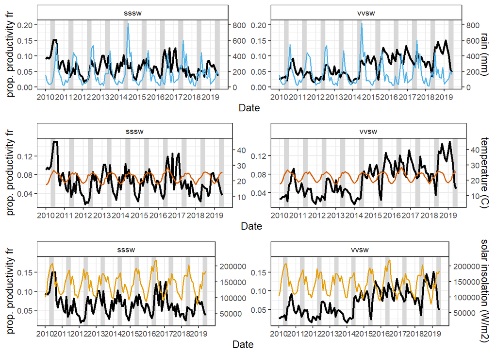

```r
# plot time series of proportional flowering productivity
base_iplot <- ggplot(kphen_pop_fr,
                     aes(x = Date, y = productivity)) +
                geom_line(size = 1) +
                geom_rect(aes(xmin = as.Date('2010-10-01'), xmax = as.Date('2010-12-31'),
                      ymin = -Inf, ymax = Inf), alpha = 0.005) +
                geom_rect(aes(xmin = as.Date('2011-10-01'), xmax = as.Date('2011-12-31'),
                      ymin = -Inf, ymax = Inf), alpha = 0.005) +
                geom_rect(aes(xmin = as.Date('2012-10-01'), xmax = as.Date('2012-12-31'),
                      ymin = -Inf, ymax = Inf),  alpha = 0.005) +
                geom_rect(aes(xmin = as.Date('2013-10-01'), xmax = as.Date('2013-12-31'),
                      ymin = -Inf, ymax = Inf),  alpha = 0.005) +
                geom_rect(aes(xmin = as.Date('2014-10-01'), xmax = as.Date('2014-12-31'),
                      ymin = -Inf, ymax = Inf),  alpha = 0.005) +
                geom_rect(aes(xmin = as.Date('2015-10-01'), xmax = as.Date('2015-12-31'),
                      ymin = -Inf, ymax = Inf),  alpha = 0.005) +
                geom_rect(aes(xmin = as.Date('2016-10-01'), xmax = as.Date('2016-12-31'),
                      ymin = -Inf, ymax = Inf),  alpha = 0.005) +
                geom_rect(aes(xmin = as.Date('2017-10-01'), xmax = as.Date('2017-12-31'),
                      ymin = -Inf, ymax = Inf),  alpha = 0.005) +
                geom_rect(aes(xmin = as.Date('2018-10-01'), xmax = as.Date('2018-12-31'),
                      ymin = -Inf, ymax = Inf), alpha = 0.005) +
                geom_rect(aes(xmin = as.Date('2019-10-01'), xmax = as.Date('2019-12-31'),
                      ymin = -Inf, ymax = Inf),  alpha = 0.005) +
                scale_x_date(breaks = function(x) seq.Date(from = as.Date('2010-07-01'),
                                                           to = as.Date('2019-12-31'),
                                                           by = "1 year"),
                             date_labels = "%Y") +
                theme_bw(base_size=10) +
                theme(strip.background = element_rect('white')) +
                facet_wrap(~dataset,
                           ncol=2,
                           strip.position = 'top',
                           scales = 'free_y')

# get rain plot
rain_plot <- base_iplot +
               geom_line(aes(x = Date, y =rain/4000),
                          linetype = 'solid',
                          colour = '#56B4E9',
                          linewidth = 0.7) +
                scale_y_continuous(sec.axis = sec_axis(~.*4000, name = 'rain (mm)'),
                                   name = 'prop. productivity fr')

temp_plot <- base_iplot +
               geom_line(aes(x = Date, y =temp/300),
                          linetype = 'solid',
                          colour = '#D55E00',
                          linewidth = 0.7) +
              scale_y_continuous(sec.axis = sec_axis(~.*300, name = 'temperature (C)'),
                                 name = 'prop. productivity fr')

rad_plot <- base_iplot +
              geom_line(aes(x = Date, y = rad/1200000),
                          linetype = 'solid',
                          colour = '#E69F00',
                          linewidth = 0.7) +
              scale_y_continuous(sec.axis = sec_axis(~.*1200000, name = 'solar insolation (W/m2)'),
                                 name = 'prop. productivity fr')


# arrange figure and output
plot_grid(rain_plot, temp_plot, rad_plot, nrow = 3, ncol=1)
```

#### Model

Prop of individuals and taxa flowering/fruiting will be modeled as logistic regression  
Proportional productivity will be modeled as a beta regression

Format data for generalized linear models

Relevant columns:  
Respose variables  
individuals - prop of individuals flowering or fruiting sprich - prop of taxa flowering or fruiting individuals  
productivity - fruiting or flowering productivity (sum of phenology across individuals)

```r
# format covariates
# copy over tables
comm_fr_std <- kphen_pop_fr
comm_fl_std <- kphen_pop_fl

# get rid of records before 2010
comm_fr_std <- comm_fr_std %>% filter(year > 2010)
comm_fl_std <- comm_fl_std %>% filter(year > 2010)

# create an individual and taxa as a metric of effort
comm_fr_std$indi_cov <- comm_fr_std$individuals
comm_fl_std$indi_cov <- comm_fl_std$individuals
comm_fr_std$sr_cov <- comm_fr_std$sprich
comm_fl_std$sr_cov <- comm_fl_std$sprich

# standardize the continuous variables
# calculates standardization for fruit phenology table
process <- preProcess(comm_fr_std[,c('rain','temp','rad','indi_cov','sr_cov')],
                      method= c('center','scale'))

# apply standardization
comm_fr_std[,c('rain','temp','rad','indi_cov','sr_cov')] <- predict(process, comm_fr_std[,c('rain','temp','rad','indi_cov','sr_cov')])

# calculates normalization for flower phenology table
process <- preProcess(comm_fl_std[,c('rain','temp','rad','indi_cov','sr_cov')],
                      method= c('center','scale'))

# apply standardization
comm_fl_std[,c('rain','temp','rad','indi_cov','sr_cov')] <- predict(process, comm_fl_std[,c('rain','temp','rad','indi_cov','sr_cov')])

# set transition, year, month and dataset as factors
comm_fr_std$year <- as.factor(comm_fr_std$year)
comm_fl_std$year <- as.factor(comm_fl_std$year)
comm_fr_std$month <- as.factor(comm_fr_std$month)
comm_fl_std$month <- as.factor(comm_fl_std$month)
comm_fr_std$transition <- as.factor(comm_fr_std$transition)
comm_fl_std$transition <- as.factor(comm_fl_std$transition)
comm_fr_std$dataset <- factor(comm_fr_std$dataset, levels =c('vvsw','sssw'))
comm_fl_std$dataset <- factor(comm_fl_std$dataset, levels =c('vvsw','sssw'))

# assign contrasts for incorporating categorical variables into GLM
# treatment contrast with Vatovavy as reference
contrasts(comm_fl_std$dataset) <- contr.treatment(levels(comm_fl_std$dataset))
contrasts(comm_fr_std$dataset) <- contr.treatment(levels(comm_fr_std$dataset))

# treatment contrast with period out of the dry-to-wet season transition as reference
contrasts(comm_fl_std$transition) <- contr.treatment(levels(comm_fl_std$transition))
contrasts(comm_fr_std$transition) <- contr.treatment(levels(comm_fr_std$transition))

# sum-to-zero contrast
contrasts(comm_fl_std$year) <- contr.sum(levels(comm_fl_std$year))
contrasts(comm_fr_std$year) <- contr.sum(levels(comm_fr_std$year))
```

```r
# productivity modeled using beta regression
# transformation since flower productivity is 0 for one month in Sangasanga
# betareg can only support y in (0,1)
y_betareg_format <- function(y){
    n.obs <- sum(!is.na(y))
    (y * (n.obs - 1) + 0.5) / n.obs
}

comm_fl_std$productivity_br <- y_betareg_format(comm_fl_std$productivity) # run transformation
```

Visualize response distributions

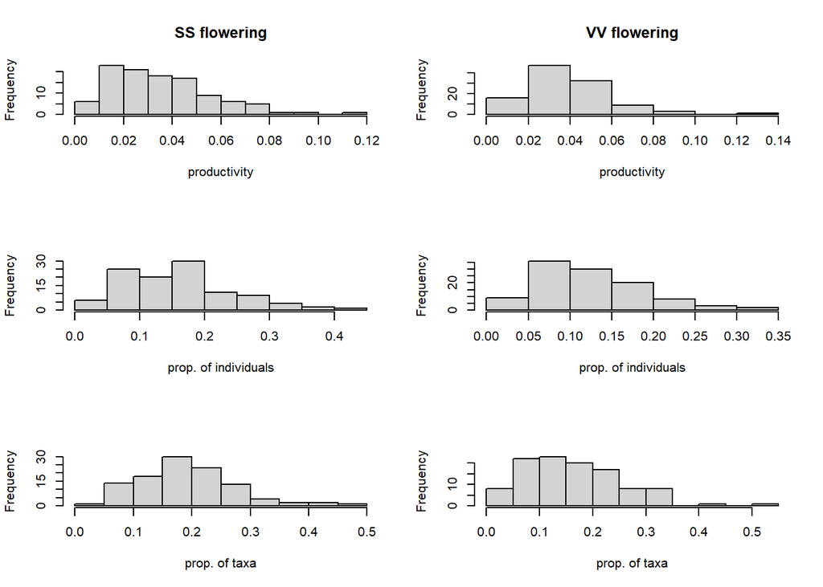

```r
par(mfrow = c(3,2))

# Visualize flowering distributions
# plot distribution of flowering productivity for Sangasanga
hist(comm_fl_std$productivity[which(comm_fl_std$dataset =='sssw')],
     xlab = 'productivity',
     main = 'SS flowering')

# plot distribution of flowering productivity for Vatovavy
hist(comm_fl_std$productivity[which(comm_fl_std$dataset =='vvsw')],
     xlab = 'productivity',
     main = 'VV flowering')

# plot distribution of prop. of individuals flowering for Sangasanga
hist(comm_fl_std$individuals[which(comm_fl_std$dataset =='sssw')],
     xlab = 'prop. of individuals',
     main = '')

# plot distribution of prop. of individuals flowering for Vatovavy
hist(comm_fl_std$individuals[which(comm_fl_std$dataset =='vvsw')],
     xlab = 'prop. of individuals',
     main = '')

# plot distribution of prop. of taxa flowering for Sangasanga
hist(comm_fl_std$sprich[which(comm_fl_std$dataset =='sssw')],
     xlab = 'prop. of taxa',
     main = '')

# plot distribution of prop. of taxa flowering for Vatovavy
hist(comm_fl_std$sprich[which(comm_fl_std$dataset =='vvsw')],
     xlab = 'prop. of taxa',
     main = '')
```

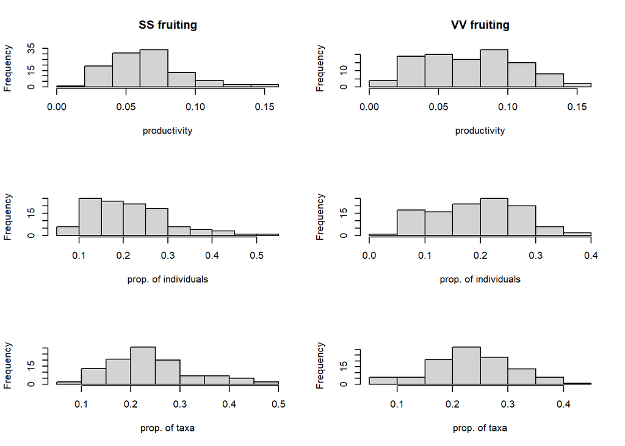

```r
# Visualize fruiting distributions
# plot distribution of fruiting productivity for Sangasanga
hist(comm_fr_std$productivity[which(comm_fr_std$dataset =='sssw')],
     xlab = 'productivity',
     main = 'SS fruiting')

# plot distribution of fruiting productivity for Vatovavy
hist(comm_fr_std$productivity[which(comm_fr_std$dataset =='vvsw')],
     xlab = 'productivity',
     main = 'VV fruiting')

# plot distribution of prop. of individuals fruiting for Sangasanga
hist(comm_fr_std$individuals[which(comm_fr_std$dataset =='sssw')],
     xlab = 'prop. of individuals',
     main = '')

# plot distribution of prop. of individuals fruiting for Vatovavy
hist(comm_fr_std$individuals[which(comm_fr_std$dataset =='vvsw')],
     xlab = 'prop. of individuals',
     main = '')

# plot distribution of prop. of taxa fruiting for Sangasanga
hist(comm_fr_std$sprich[which(comm_fr_std$dataset =='sssw')],
     xlab = 'prop. of taxa',
     main = '')

# plot distribution of prop. of taxa fruiting for Vatovavy
hist(comm_fr_std$sprich[which(comm_fr_std$dataset =='vvsw')],
     xlab = 'prop. of taxa',
     main = '')
```

Look at interaction plots between dry-to-wet season transition and community flowering

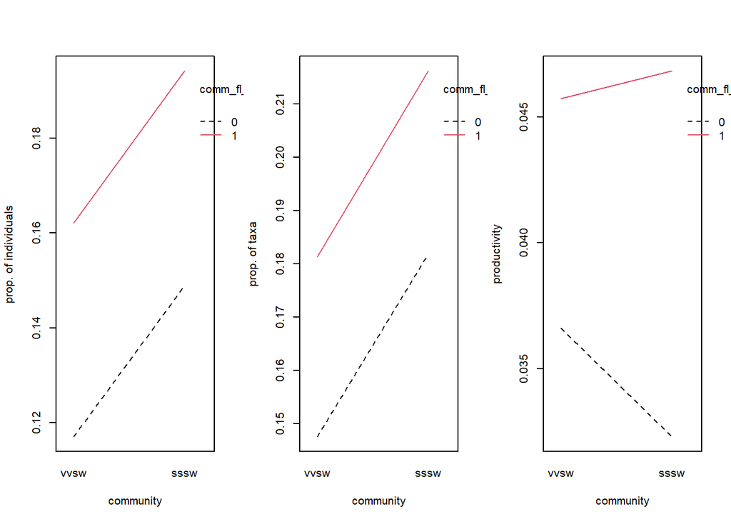

```r
par(mfrow = c(1,3))
# interaction plot for flowering individuals
interaction.plot(comm_fl_std$dataset,
                 comm_fl_std$transition,
                 comm_fl_std$individuals,
                 col = 1:2,
                 fixed =T,
                 xlab = 'community',
                 ylab = 'prop. of individuals')

# interaction plot for flowering taxa
interaction.plot(comm_fl_std$dataset,
                 comm_fl_std$transition,
                 comm_fl_std$sprich,
                 col = 1:2,
                 fixed =T,
                 xlab = 'community',
                 ylab = 'prop. of taxa')

# interaction plot for flowering productivity
interaction.plot(comm_fl_std$dataset,
                 comm_fl_std$transition,
                 comm_fl_std$productivity,
                 col = 1:2,
                 fixed =T,
                 xlab = 'community',
                 ylab = 'productivity')
```

no transition interactions for flower individual and species rich signs of transition interaction for flower productivity  
Look at interaction plots between year and community

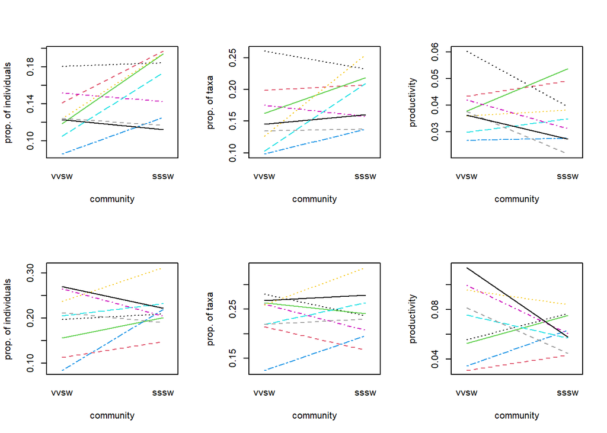

```r
par(mfrow = c(2,3))
# interaction plot for flowering individuals
interaction.plot(comm_fl_std$dataset,
                 comm_fl_std$year,
                 comm_fl_std$individuals,
                 col = 1:9,
                 fixed =T,
                 xlab = 'community',
                 ylab = 'prop. of individuals',
                 legend = F)

# interaction plot for flowering taxa
interaction.plot(comm_fl_std$dataset,
                 comm_fl_std$year,
                 comm_fl_std$sprich,
                 col = 1:9,
                 fixed =T,
                 xlab = 'community',
                 ylab = 'prop. of taxa',
                 legend = F)

# interaction plot for flowering productivity
interaction.plot(comm_fl_std$dataset,
                 comm_fl_std$year,
                 comm_fl_std$productivity,
                 col = 1:9,
                 fixed =T,
                 xlab = 'community',
                 ylab = 'productivity',
                 legend = F)

# interaction plot for fruiting individuals
interaction.plot(comm_fr_std$dataset,
                 comm_fr_std$year,
                 comm_fr_std$individuals,
                 col = 1:9,
                 fixed =T,
                 xlab = 'community',
                 ylab = 'prop. of individuals',
                 legend = F)

# interaction plot for fruiting taxa
interaction.plot(comm_fr_std$dataset,
                 comm_fr_std$year,
                 comm_fr_std$sprich,
                 col = 1:9,
                 fixed =T,
                 xlab = 'community',
                 ylab = 'prop. of taxa',
                 legend = F)

# interaction plot for fruiting productivity
interaction.plot(comm_fr_std$dataset,
                 comm_fr_std$year,
                 comm_fr_std$productivity,
                 col = 1:9,
                 fixed =T,
                 xlab = 'community',
                 ylab = 'productivity',
                 legend = F)
```

year interactions for all flower and fruit metrics  
Look at interaction plots between rain and community

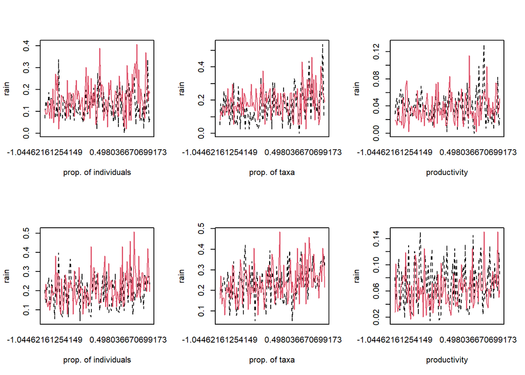

```r
par(mfrow = c(2,3))
# interaction plot for flowering individuals
interaction.plot(comm_fl_std$rain,
                 comm_fl_std$dataset,
                 comm_fl_std$individuals,
                 col = 1:2,
                 fixed =T,
                 ylab = 'rain',
                 xlab = 'prop. of individuals',
                 legend = F)

# interaction plot for flowering taxa
interaction.plot(comm_fl_std$rain,
                 comm_fl_std$dataset,
                 comm_fl_std$sprich,
                 col = 1:2,
                 fixed =T,
                 ylab = 'rain',
                 xlab = 'prop. of taxa',
                 legend = F)

# interaction plot for flowering productivity
interaction.plot(comm_fl_std$rain,
                 comm_fl_std$dataset,
                 comm_fl_std$productivity,
                 col = 1:2,
                 fixed =T,
                 ylab = 'rain',
                 xlab = 'productivity',
                 legend = F)

# interaction plot for fruiting individuals
interaction.plot(comm_fr_std$rain,
                 comm_fr_std$dataset,
                 comm_fr_std$individuals,
                 col = 1:2,
                 fixed =T,
                 ylab = 'rain',
                 xlab = 'prop. of individuals',
                 legend = F)

# interaction plot for fruiting taxa
interaction.plot(comm_fr_std$rain,
                 comm_fr_std$dataset,
                 comm_fr_std$sprich,
                 col = 1:2,
                 fixed =T,
                 ylab = 'rain',
                 xlab = 'prop. of taxa',
                 legend = F)

# interaction plot for fruiting productivity
interaction.plot(comm_fr_std$rain,
                 comm_fr_std$dataset,
                 comm_fr_std$productivity,
                 col = 1:2,
                 fixed =T,
                 ylab = 'rain',
                 xlab = 'productivity',
                 legend = F)
```

rain interactions for all metrics  
Look at interaction plots between temperature and community

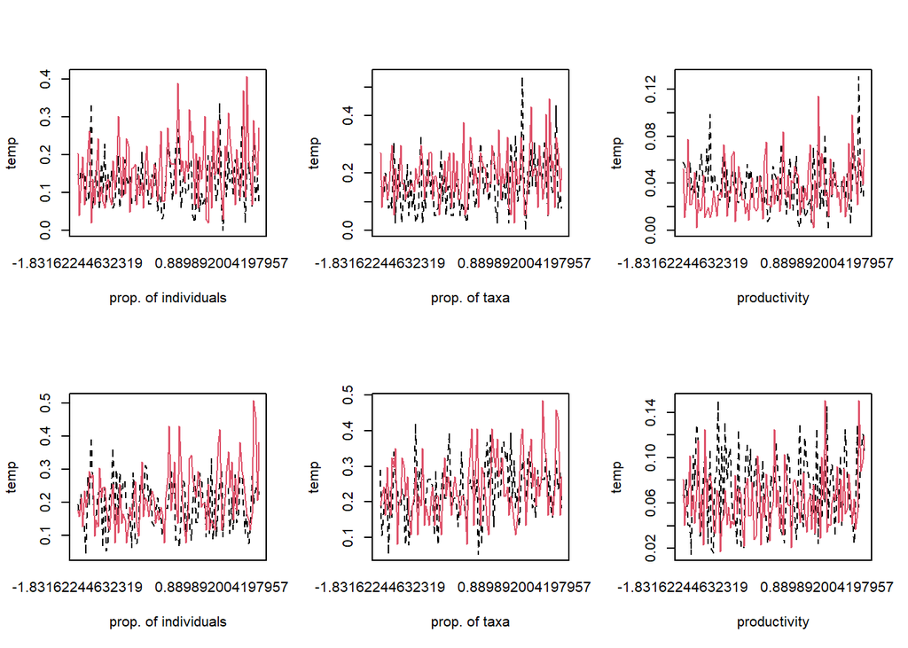

```r
par(mfrow = c(2,3))
# interaction plot for flowering individuals
interaction.plot(comm_fl_std$temp,
                 comm_fl_std$dataset,
                 comm_fl_std$individuals,
                 col = 1:2,
                 fixed =T,
                 ylab = 'temp',
                 xlab = 'prop. of individuals',
                 legend = F)

# interaction plot for flowering taxa
interaction.plot(comm_fl_std$temp,
                 comm_fl_std$dataset,
                 comm_fl_std$sprich,
                 col = 1:2,
                 fixed =T,
                 ylab = 'temp',
                 xlab = 'prop. of taxa',
                 legend = F)

# interaction plot for flowering productivity
interaction.plot(comm_fl_std$temp,
                 comm_fl_std$dataset,
                 comm_fl_std$productivity,
                 col = 1:2,
                 fixed =T,
                 ylab = 'temp',
                 xlab = 'productivity',
                 legend = F)

# interaction plot for fruiting individuals
interaction.plot(comm_fr_std$temp,
                 comm_fr_std$dataset,
                 comm_fr_std$individuals,
                 col = 1:2,
                 fixed =T,
                 ylab = 'temp',
                 xlab = 'prop. of individuals',
                 legend = F)

# interaction plot for fruiting taxa
interaction.plot(comm_fr_std$temp,
                 comm_fr_std$dataset,
                 comm_fr_std$sprich,
                 col = 1:2,
                 fixed =T,
                 ylab = 'temp',
                 xlab = 'prop. of taxa',
                 legend = F)

# interaction plot for fruiting productivity
interaction.plot(comm_fr_std$temp,
                 comm_fr_std$dataset,
                 comm_fr_std$productivity,
                 col = 1:2,
                 fixed =T,
                 ylab = 'temp',
                 xlab = 'productivity',
                 legend = F)
```

temp interactions for all metrics  
Look at interaction plots between solar insolation and community

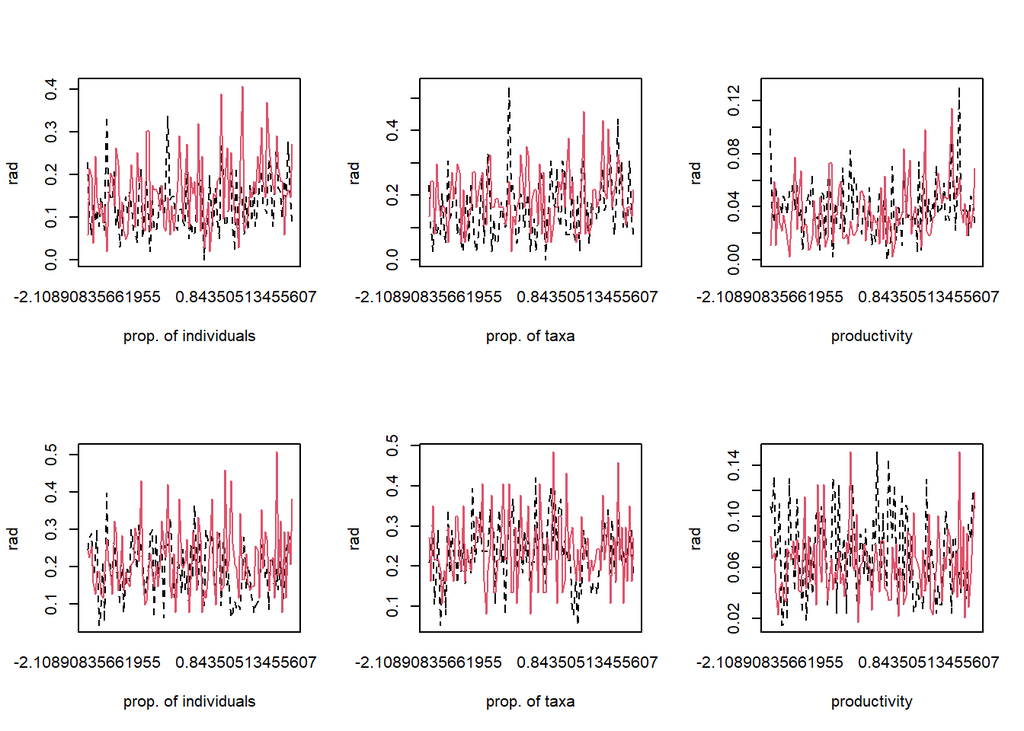

```r
par(mfrow = c(2,3))
# interaction plot for flowering individuals
interaction.plot(comm_fl_std$rad,
                 comm_fl_std$dataset,
                 comm_fl_std$individuals,
                 col = 1:2,
                 fixed =T,
                 ylab = 'rad',
                 xlab = 'prop. of individuals',
                 legend = F)

# interaction plot for flowering taxa
interaction.plot(comm_fl_std$rad,
                 comm_fl_std$dataset,
                 comm_fl_std$sprich,
                 col = 1:2,
                 fixed =T,
                 ylab = 'rad',
                 xlab = 'prop. of taxa',
                 legend = F)

# interaction plot for flowering productivity
interaction.plot(comm_fl_std$rad,
                 comm_fl_std$dataset,
                 comm_fl_std$productivity,
                 col = 1:2,
                 fixed =T,
                 ylab = 'rad',
                 xlab = 'productivity',
                 legend = F)

# interaction plot for fruiting individuals
interaction.plot(comm_fr_std$rad,
                 comm_fr_std$dataset,
                 comm_fr_std$individuals,
                 col = 1:2,
                 fixed =T,
                 ylab = 'rad',
                 xlab = 'prop. of individuals',
                 legend = F)

# interaction plot for fruiting taxa
interaction.plot(comm_fr_std$rad,
                 comm_fr_std$dataset,
                 comm_fr_std$sprich,
                 col = 1:2,
                 fixed =T,
                 ylab = 'rad',
                 xlab = 'prop. of taxa',
                 legend = F)

# interaction plot for fruiting productivity
interaction.plot(comm_fr_std$rad,
                 comm_fr_std$dataset,
                 comm_fr_std$productivity,
                 col = 1:2,
                 fixed =T,
                 ylab = 'rad',
                 xlab = 'productivity',
                 legend = F)
```

solar insolation interactions for all metrics  
GLM evaluation functions

```r
# function to calculate pseudo R2 for logistic
pseudor2 <- function(model){
  return(1 - (model$deviance/model$null.deviance))
}

# Function to generate AIC table and best model parameters
aic_best <- function(models, stage, response, mtype = F){
  # models: list of models
  # stage: flower or fruit
  # response: metric
  # mtype: model distribution, mtype = T then beta model, mtype = F (default) then model is logistic

  # calculate AIC from list of models
  aictab <- as.data.frame(aictab(models,sort=T, second.ord = T))
  # if mtype is true, then use PseudoR2
  if (mtype == T) {
    aictab$pseudor2 <- unlist(lapply(models, PseudoR2)) # calculate pseudo R2
    aictab$pseudoR2 <- unlist(lapply(models, function(x) summary(x)$pseudo.r.squared)) # calculate pseudo R2
  }
  # else mtype is false and use pseudoR2 function
  else {
    aictab$pseudor2 <- unlist(lapply(models, pseudor2)) # calculate pseudo R2
    aictab$pseudoR2 <- unlist(lapply(models, PseudoR2)) # calculate pseudo R2
  }
  # get best model identifier
  bestid <- as.integer(rownames(aictab[1,]))

  if (mtype == T){ # if beta model
    # extract the model parameter coefficient means
    best_df <- as.data.frame(rbind(summary(models[[bestid]])$coefficients$mean,
                                   summary(models[[bestid]])$coefficients$precision))

    # calculate the model parameter 95% confidence intervals
    best_df <- cbind(best_df,confint(models[[bestid]]))
  }
  else{ # else logistic model
    # extract the model parameter coefficient means and 95% confidence intervals
    best_df <- as.data.frame(cbind(summary(models[[bestid]])$coefficients,
                                   confint(models[[bestid]])))
  }
  # assign stage
  best_df$stage <- stage
  # assign metric
  best_df$metric <- response
  # save results
  write.csv(aictab, 'aictab.csv')
  # return the AIC table, best model paramtere summary and best model
  return(list(aictab, best_df, models[[bestid]]))
}

# Function to plot residuals against fitted.values
residual_plot <- function(mod, data, metric){
  # mod: best model
  # data: dataframe
  # metric: response

  # put calculated residuals and extracted fitted values in df
  glm2_plot <- data.frame("predict" = mod$fitted.values, "res" = mod$fitted.values - data[,metric]) # put calculated residuals and extracted fitted values in df
  # title of the plot
  tname <- paste("Predicted ", metric, " v. Residuals: \n", as.character(mod$call[1]), as.character(mod$call[2])) # title of the plot
  g <- ggplot(glm2_plot, aes(x = predict, y = res)) +
    geom_point(size = 2, color = "black") +
    theme_bw(base_size = 10) +
    labs(title = tname, x = paste("predicted", metric), y = "residuals") # set the graph labels
  return(g)
}
```

**GLM for flowering individuals with community interactions**

```r
# using zero sum contrast on onset and years. Aliased: year 2019
mod1 <- glm(individuals~rain*dataset +rad*dataset + transition + year*dataset,
            binomial('logit'),data = comm_fl_std, weights = n)

mod2 <- glm(individuals~ rain*dataset +temp*dataset + transition + year*dataset,
            binomial('logit'),data = comm_fl_std, weights = n)

mod3 <- glm(individuals~rain*dataset +rad + transition + year*dataset,
            binomial('logit'),data = comm_fl_std, weights = n)

mod4 <- glm(individuals~rain*dataset +temp + transition + year*dataset,
            binomial('logit'),data = comm_fl_std, weights = n)

mod5 <- glm(individuals~rain*dataset + transition + year*dataset,
            binomial('logit'),data = comm_fl_std, weights = n)

mod6 <- glm(individuals~rain*dataset + transition + year,
            binomial('logit'),data = comm_fl_std, weights = n)

# generate aic and extract information from best model
ikfli <- aic_best(list(mod1,mod2,mod3,mod4,mod5, mod6), 'flower','individual')
# assign best model object
fli_best <- ikfli[[3]]

# print aic table
ikfli[[1]]
```

```
##   Modnames  K     AICc Delta_AICc     ModelLik       AICcWt        LL    Cum.Wt
## 2     Mod2 23 1661.231   0.000000 1.000000e+00 4.661812e-01 -804.7403 0.4661812
## 5     Mod5 21 1662.489   1.258660 5.329489e-01 2.484507e-01 -807.8632 0.7146319
## 4     Mod4 22 1663.574   2.343209 3.098694e-01 1.444553e-01 -807.1651 0.8590871
## 3     Mod3 22 1664.940   3.709936 1.564579e-01 7.293774e-02 -807.8485 0.9320249
## 1     Mod1 23 1665.081   3.850866 1.458126e-01 6.797509e-02 -806.6657 1.0000000
## 6     Mod6 13 1694.177  32.946956 7.009053e-08 3.267488e-08 -833.1878 1.0000000
##    pseudor2  pseudoR2
## 2 0.3035961 0.1594441
## 5 0.3074164 0.1614504
## 4 0.3012494 0.1582116
## 3 0.3026053 0.1589237
## 1 0.3012203 0.1581963
## 6 0.2509741 0.1318078
```

```r
# print summary of best model
summary(fli_best)
```

```
##
## Call:
## glm(formula = individuals ~ rain * dataset + temp * dataset +
##     transition + year * dataset, family = binomial("logit"),
##     data = comm_fl_std, weights = n)
##
## Deviance Residuals:
##     Min       1Q   Median       3Q      Max
## -5.1706  -1.2469  -0.2275   1.0794   5.5455
##
## Coefficients:
##                   Estimate Std. Error z value Pr(>|z|)
## (Intercept)       -2.04213    0.03267 -62.499  < 2e-16 ***
## rain               0.04512    0.03751   1.203  0.22897
## datasetsssw        0.24733    0.03953   6.258 3.91e-10 ***
## temp              -0.09065    0.03851  -2.354  0.01858 *
## transition1        0.39184    0.05063   7.740 9.94e-15 ***
## year1              0.43368    0.07222   6.005 1.91e-09 ***
## year2              0.12524    0.07850   1.595  0.11063
## year3             -0.08248    0.08387  -0.984  0.32536
## year4             -0.42992    0.09513  -4.519 6.21e-06 ***
## year5             -0.22367    0.08841  -2.530  0.01141 *
## year6              0.22859    0.07698   2.970  0.00298 **
## year7             -0.01457    0.08244  -0.177  0.85975
## year8             -0.02256    0.08226  -0.274  0.78388
## rain:datasetsssw   0.09086    0.04713   1.928  0.05387 .
## datasetsssw:temp   0.10499    0.04769   2.202  0.02770 *
## datasetsssw:year1 -0.24287    0.10068  -2.412  0.01585 *
## datasetsssw:year2  0.15143    0.10424   1.453  0.14632
## datasetsssw:year3  0.34267    0.10868   3.153  0.00162 **
## datasetsssw:year4  0.16983    0.12466   1.362  0.17307
## datasetsssw:year5  0.30485    0.11428   2.667  0.00764 **
## datasetsssw:year6 -0.31066    0.10893  -2.852  0.00434 **
## datasetsssw:year7  0.28165    0.10748   2.621  0.00878 **
## datasetsssw:year8 -0.33203    0.11673  -2.844  0.00445 **
## ---
## Signif. codes:  0 '***' 0.001 '**' 0.01 '*' 0.05 '.' 0.1 ' ' 1
##
## (Dispersion parameter for binomial family taken to be 1)
##
##     Null deviance: 1008.02  on 215  degrees of freedom
## Residual deviance:  698.14  on 193  degrees of freedom
## AIC: 1655.5
##
## Number of Fisher Scoring iterations: 4
```

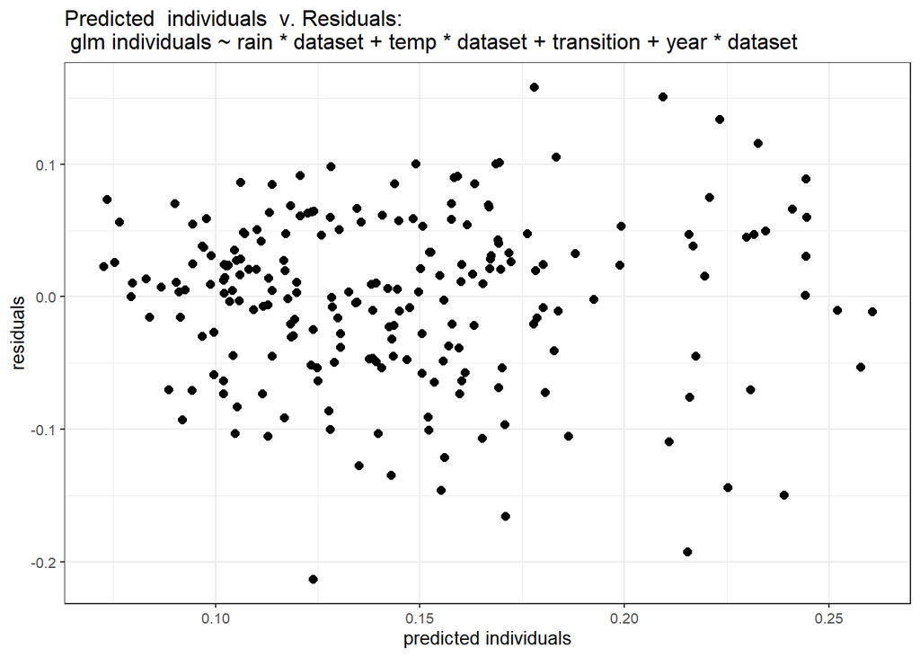

```r
# plot residuals
residual_plot(fli_best, comm_fl_std, 'individuals')
```

Visualize relationship between individual flowering and best model variables

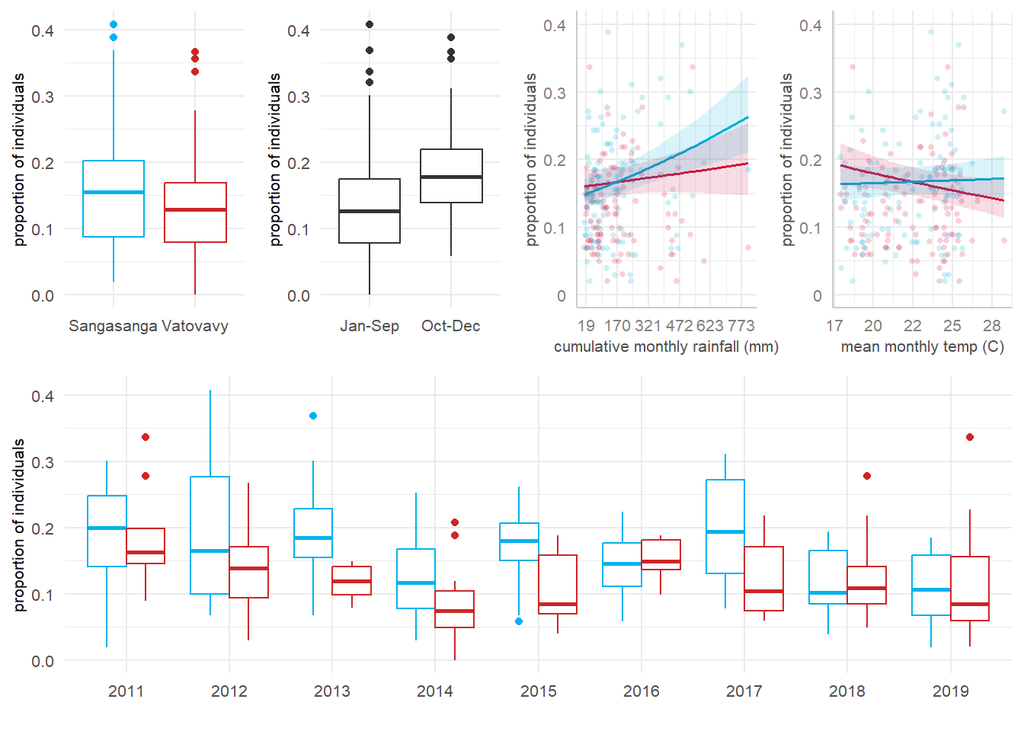

```r
# plot boxplot of prop. of individuals flowering within and outside of the dry-to-wet season transition
flitran <- ggplot(kphen_pop_fl,
                  aes(y = individuals,
                      x = as.factor(transition),
                      group = as.factor(transition))) +
                geom_boxplot(aes()) +
                theme_minimal() +
                ylab('proportion of individuals') +
                xlab('') +
                theme(legend.position = 'None',
                      text = element_text(size = 8),
                      axis.text = element_text(size = 8)) +
                scale_x_discrete(labels = c('Jan-Sep', 'Oct-Dec'))

# plot boxplot of prop. of individuals flowering between communites
flic <- ggplot(kphen_pop_fl,
               aes(y = individuals,
                   x = dataset,
                   group = dataset)) +
            geom_boxplot(aes(color = dataset)) +
            theme_minimal() +
            ylab('proportion of individuals') +
            xlab('') +
            theme(legend.position = 'None',
                  text = element_text(size = 8),
                  axis.text = element_text(size = 8)) +
            scale_color_manual(values = c("sssw" = 'deepskyblue2', "vvsw" = 'firebrick3')) +
            scale_x_discrete(labels = c('Sangasanga','Vatovavy'))

# plot estimated relationship between rain and prop. of individuals flowering
flir <- plot(ggpredict(fli_best,
                       terms = c("rain[all]","dataset"),
                       type = 'fe'),
                       ci = T,
                       add.data =T,
                       colors = 'metro',
                       jitter = 0.0001,
                       show.legend= F,
                       show.title = F,
                       dot.size=1,
                       dot.alpha=0.2) +
              xlab('cumulative monthly rainfall (mm)') +
              ylab('proportion of individuals') +
              scale_x_continuous(labels = ~round(.*sd(kphen_pop_fl$rain) + mean(kphen_pop_fl$rain),0)) +
              scale_y_continuous(limits = c(0, 0.4),
                                 labels = c(0,0.1,0.2,0.3,0.4)) +
              theme(legend.position = 'None',
                    text = element_text(size = 8),
                    axis.text = element_text(size = 8))
# plot estimated relationship between temp and prop. of individuals flowering
flit <- plot(ggpredict(fli_best,
                       terms = c("temp[all]","dataset"),
                       type = 'fe'),
                       ci = T,
                       add.data =T,
                       colors = 'metro',
                       jitter = 0.0001,
                       show.legend= F,
                       show.title = F,
                       dot.size=1,
                       dot.alpha=0.2) +
              xlab('mean monthly temp (C)') +
              ylab('proportion of individuals') +
              scale_x_continuous(labels = ~round(.*sd(kphen_pop_fl$temp) + mean(kphen_pop_fl$temp),0)) +
              scale_y_continuous(limits = c(0, 0.4),
                                 labels = c(0,0.1,0.2,0.3,0.4)) +
              theme(legend.position = 'None',
                    text = element_text(size = 8),
                    axis.text = element_text(size = 8))
# plot boxplot of prop. of individuals flowering across years
fliy <- ggplot(kphen_pop_fl %>% filter(year > 2010),
               aes(y = individuals,
                   x = as.factor(year),
                   color = dataset)) +
              geom_boxplot(position = "dodge") +
              theme_minimal() +
              ylab('proportion of individuals') +
              xlab('') +
              theme(legend.position = 'None',
                    text = element_text(size = 8),
                    axis.text = element_text(size = 8)) +
              scale_color_manual(values = c("sssw" = 'deepskyblue2', "vvsw" = 'firebrick3'))

# arrange plots into one figure and view
grid.arrange(arrangeGrob(flic, flitran,flir,flit, ncol=4, nrow=1),
         arrangeGrob(fliy, ncol=1, nrow=1),
         ncol = 1,nrow=2)
```

**GLM for flower diversity with community interactions**

```r
# using zero sum contrast on onset and years. Aliased: year 2019
mod1 <- glm(sprich~rain*dataset +rad*dataset + transition + year*dataset,
            binomial('logit'),
            data = comm_fl_std,
            weights = ns)

mod2 <- glm(sprich~ rain*dataset +temp*dataset + transition + year*dataset,
            binomial('logit'),
            data = comm_fl_std,
            weights = ns)

mod3 <- glm(sprich~ rain + transition + year*dataset,
            binomial('logit'),
            data = comm_fl_std,
            weights = ns)

mod4 <- glm(sprich~ rain + transition + year,
            binomial('logit'),
            data = comm_fl_std,
            weights = ns)

# generate aic and extract information from best model
ikflsp <- aic_best(list(mod1,mod2,mod3,mod4), 'flower','species')

# assign best model object
flsp_best <- ikflsp[[3]]

# print aic table
ikflsp[[1]]
```

```
##   Modnames  K     AICc Delta_AICc     ModelLik       AICcWt        LL    Cum.Wt
## 3     Mod3 20 1097.861   0.000000 1.000000e+00 8.098623e-01 -526.7767 0.8098623
## 2     Mod2 23 1101.954   4.093207 1.291729e-01 1.046123e-01 -525.1021 0.9144746
## 1     Mod1 23 1102.357   4.496102 1.056049e-01 8.552539e-02 -525.3036 1.0000000
## 4     Mod4 11 1132.287  34.425821 3.346016e-08 2.709812e-08 -554.4964 1.0000000
##    pseudor2   pseudoR2
## 3 0.3582971 0.14504344
## 2 0.3591070 0.14537130
## 1 0.3523745 0.14264589
## 4 0.2409278 0.09753077
```

```r
# print summary of best model
summary(flsp_best)
```

```
##
## Call:
## glm(formula = sprich ~ rain + transition + year * dataset, family = binomial("logit"),
##     data = comm_fl_std, weights = ns)
##
## Deviance Residuals:
##     Min       1Q   Median       3Q      Max
## -3.1783  -0.8101  -0.0927   0.7230   3.0688
##
## Coefficients:
##                   Estimate Std. Error z value Pr(>|z|)
## (Intercept)       -1.80824    0.04815 -37.557  < 2e-16 ***
## rain               0.16310    0.02865   5.693 1.25e-08 ***
## transition1        0.25485    0.06603   3.860 0.000113 ***
## year1              0.69056    0.10313   6.696 2.14e-11 ***
## year2              0.33440    0.11153   2.998 0.002714 **
## year3              0.09074    0.11934   0.760 0.447046
## year4             -0.47954    0.14421  -3.325 0.000884 ***
## year5             -0.49452    0.14245  -3.472 0.000517 ***
## year6              0.22334    0.11640   1.919 0.055033 .
## year7             -0.19847    0.13075  -1.518 0.129027
## year8             -0.13971    0.12763  -1.095 0.273674
## datasetsssw        0.26350    0.06041   4.362 1.29e-05 ***
## year1:datasetsssw -0.41927    0.14909  -2.812 0.004921 **
## year2:datasetsssw -0.21076    0.15764  -1.337 0.181237
## year3:datasetsssw  0.10487    0.16210   0.647 0.517650
## year4:datasetsssw  0.11790    0.19332   0.610 0.541952
## year5:datasetsssw  0.58533    0.18040   3.245 0.001176 **
## year6:datasetsssw -0.39051    0.16856  -2.317 0.020518 *
## year7:datasetsssw  0.60231    0.16758   3.594 0.000325 ***
## year8:datasetsssw -0.23979    0.18121  -1.323 0.185741
## ---
## Signif. codes:  0 '***' 0.001 '**' 0.01 '*' 0.05 '.' 0.1 ' ' 1
##
## (Dispersion parameter for binomial family taken to be 1)
##
##     Null deviance: 497.45  on 215  degrees of freedom
## Residual deviance: 322.16  on 196  degrees of freedom
## AIC: 1093.6
##
## Number of Fisher Scoring iterations: 4
```

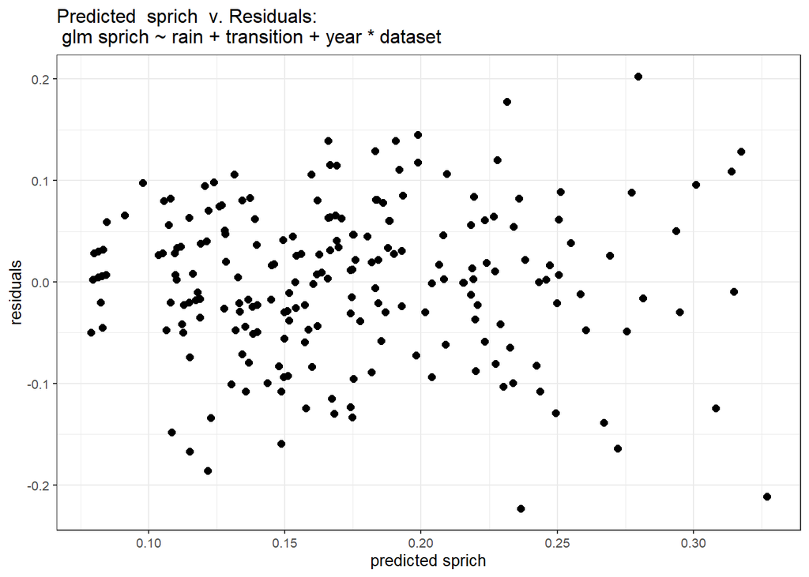

```r
# plot residuals
residual_plot(ikflsp[[3]], comm_fl_std, 'sprich')
```

Visualize relationship between taxa flowering and best model variables

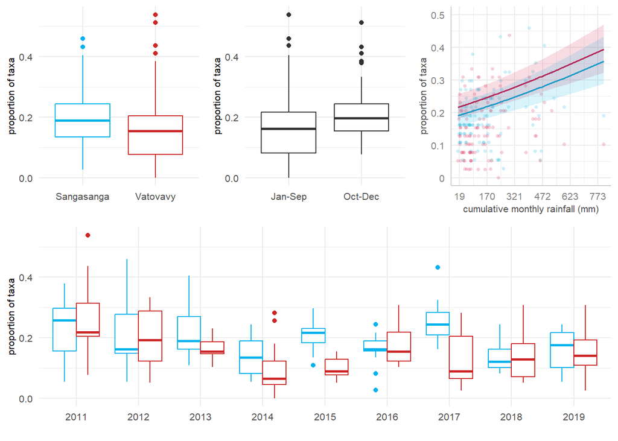

```r
# plot boxplot of prop. of taxa flowering within and outside of the dry-to-wet season transition
flsptran <- ggplot(kphen_pop_fl,
                   aes(y = sprich,
                       x = as.factor(transition),
                       group = as.factor(transition))) +
                geom_boxplot(aes()) +
                theme_minimal() +
                ylab('proportion of taxa') +
                xlab('') +
                theme(legend.position = 'None',
                      text = element_text(size = 8),
                      axis.text = element_text(size = 8)) +
                scale_x_discrete(labels = c('Jan-Sep', 'Oct-Dec'))

# plot boxplot of prop. of taxa flowering between communities
flspc <- ggplot(kphen_pop_fl,
                aes(y = sprich,
                    x = dataset,
                    group = dataset)) +
            geom_boxplot(aes(color = dataset)) +
            theme_minimal() +
            ylab('proportion of taxa') +
            xlab('') +
            theme(legend.position = 'None',
                  text = element_text(size = 8),
                  axis.text = element_text(size = 8)) +
            scale_color_manual(values = c("sssw" = 'deepskyblue2', "vvsw" = 'firebrick3')) +
            scale_x_discrete(labels = c('Sangasanga','Vatovavy'))

# plot estimated relaitonship between rain and prop. of taxa flowering
flspr <- plot(ggpredict(flsp_best, terms = c("rain[all]","dataset"), type = 'fe'),
                        ci = T,
                        add.data =T,
                        colors = 'metro',
                        jitter = 0.0001,
                        show.legend= F,
                        show.title = F,
                        dot.size=1,
                        dot.alpha=0.2) +
                xlab('cumulative monthly rainfall (mm)') +
                ylab('proportion of taxa') +
                theme(legend.position = 'None',
                      text = element_text(size = 8),
                      axis.text = element_text(size = 8)) +
                scale_x_continuous(labels = ~round(.*sd(kphen_pop_fl$rain) + mean(kphen_pop_fl$rain),0)) +
                scale_y_continuous(limits = c(0, 0.5),
                                   labels = c(0,0.1,0.2,0.3,0.4,0.5))
# plot boxplot of prop. of taxa flowering across years
flspy <- ggplot(kphen_pop_fl %>% filter(year > 2010),
                aes(y = sprich,
                    x = as.factor(year),
                    color = dataset)) +
              geom_boxplot(position = "dodge") +
              theme_minimal() +
              ylab('proportion of taxa') +
              xlab('') +
              theme(legend.position = 'None',
                    text = element_text(size = 8),
                    axis.text = element_text(size = 8)) +
              scale_color_manual(values = c("sssw" = 'deepskyblue2', "vvsw" = 'firebrick3'))

# arrange the plots and output
grid.arrange(arrangeGrob(flspc, flsptran,flspr, ncol=3, nrow=1),
             arrangeGrob(flspy, ncol=1, nrow=1),
             ncol = 1,
             nrow = 2)
```

**GLM for flower productivity with community interactions (beta)**

```r
mod1 <- betareg(productivity_br~rain*dataset +rad*dataset + transition + year*dataset,
                comm_fl_std,
                link = 'logit')

mod2 <- betareg(productivity_br~rain*dataset +temp*dataset + transition + year*dataset,
                comm_fl_std,
                link = 'logit')


mod3<- betareg(productivity_br~rain +temp*dataset + transition + year*dataset,
                comm_fl_std,
                link = 'logit')

mod4 <- betareg(productivity_br~temp*dataset + transition + year*dataset,
                comm_fl_std,
                link = 'logit')

mod5 <- betareg(productivity_br~temp*dataset + transition + year,
                comm_fl_std,
                link = 'logit')

mod6 <- betareg(productivity_br~temp*dataset + transition,
                comm_fl_std,
                link = 'logit')

# generate aic and extract information from best model
ikflp <- aic_best(list(mod1,mod2,mod3,mod4,mod5,mod6), 'flower','productivity',T)

# assign best model object
flp_best <- ikflp[[3]]

# print aic table
ikflp[[1]]
```

```
##   Modnames  K      AICc Delta_AICc     ModelLik       AICcWt       LL    Cum.Wt
## 3     Mod3 23 -1134.414   0.000000 1.0000000000 0.5440373931 593.0818 0.5440374
## 2     Mod2 24 -1132.866   1.547456 0.4612902221 0.2509591299 593.5744 0.7949965
## 4     Mod4 22 -1131.813   2.600308 0.2724898850 0.1482446867 590.5284 0.9432412
## 5     Mod5 14 -1129.808   4.605623 0.0999773534 0.0543914187 579.9487 0.9976326
## 1     Mod1 24 -1123.364  11.049854 0.0039861606 0.0021686204 588.8232 0.9998012
## 6     Mod6  6 -1118.584  15.829438 0.0003653264 0.0001987512 565.4930 1.0000000
##   pseudor2  pseudoR2
## 3       NA 0.3224029
## 2       NA 0.3528116
## 4       NA 0.3485528
## 5       NA 0.3383046
## 1       NA 0.2727973
## 6       NA 0.1540971
```

```r
# print summary of best model
summary(flp_best)
```

```
##
## Call:
## betareg(formula = productivity_br ~ rain + temp * dataset + transition +
##     year * dataset, data = comm_fl_std, link = "logit")
##
## Standardized weighted residuals 2:
##     Min      1Q  Median      3Q     Max
## -3.8963 -0.6250  0.0968  0.7308  3.0623
##
## Coefficients (mean model with logit link):
##                   Estimate Std. Error z value Pr(>|z|)
## (Intercept)       -3.29668    0.04871 -67.675  < 2e-16 ***
## rain               0.09290    0.03929   2.364  0.01806 *
## temp              -0.25310    0.05208  -4.860 1.17e-06 ***
## datasetsssw       -0.08982    0.06003  -1.496  0.13460
## transition1        0.42780    0.07802   5.483 4.19e-08 ***
## year1              0.42366    0.10148   4.175 2.98e-05 ***
## year2              0.11008    0.11155   0.987  0.32371
## year3              0.01716    0.11426   0.150  0.88059
## year4             -0.37383    0.13347  -2.801  0.00510 **
## year5             -0.24050    0.12616  -1.906  0.05661 .
## year6              0.15663    0.11112   1.410  0.15867
## year7             -0.01128    0.11732  -0.096  0.92337
## year8             -0.02588    0.11663  -0.222  0.82437
## temp:datasetsssw   0.28555    0.05992   4.765 1.89e-06 ***
## datasetsssw:year1 -0.44245    0.15799  -2.801  0.00510 **
## datasetsssw:year2  0.21270    0.15498   1.372  0.16992
## datasetsssw:year3  0.40888    0.15458   2.645  0.00817 **
## datasetsssw:year4  0.20929    0.18481   1.132  0.25743
## datasetsssw:year5  0.22606    0.17379   1.301  0.19335
## datasetsssw:year6 -0.17711    0.16519  -1.072  0.28364
## datasetsssw:year7  0.07365    0.16633   0.443  0.65792
## datasetsssw:year8 -0.32837    0.17978  -1.827  0.06777 .
##
## Phi coefficients (precision model with identity link):
##       Estimate Std. Error z value Pr(>|z|)
## (phi)   129.37      12.63   10.24   <2e-16 ***
## ---
## Signif. codes:  0 '***' 0.001 '**' 0.01 '*' 0.05 '.' 0.1 ' ' 1
##
## Type of estimator: ML (maximum likelihood)
## Log-likelihood: 593.1 on 23 Df
## Pseudo R-squared: 0.3486
## Number of iterations: 36 (BFGS) + 3 (Fisher scoring)
```

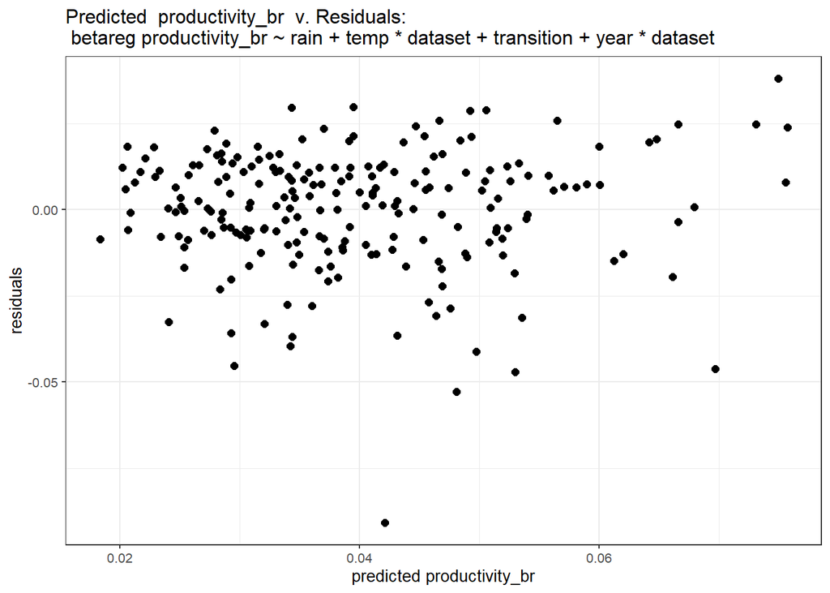

```r
# plot residuals
residual_plot(flp_best, comm_fl_std, 'productivity_br')
```

Visualize relationship between flowering productivity and best model variables

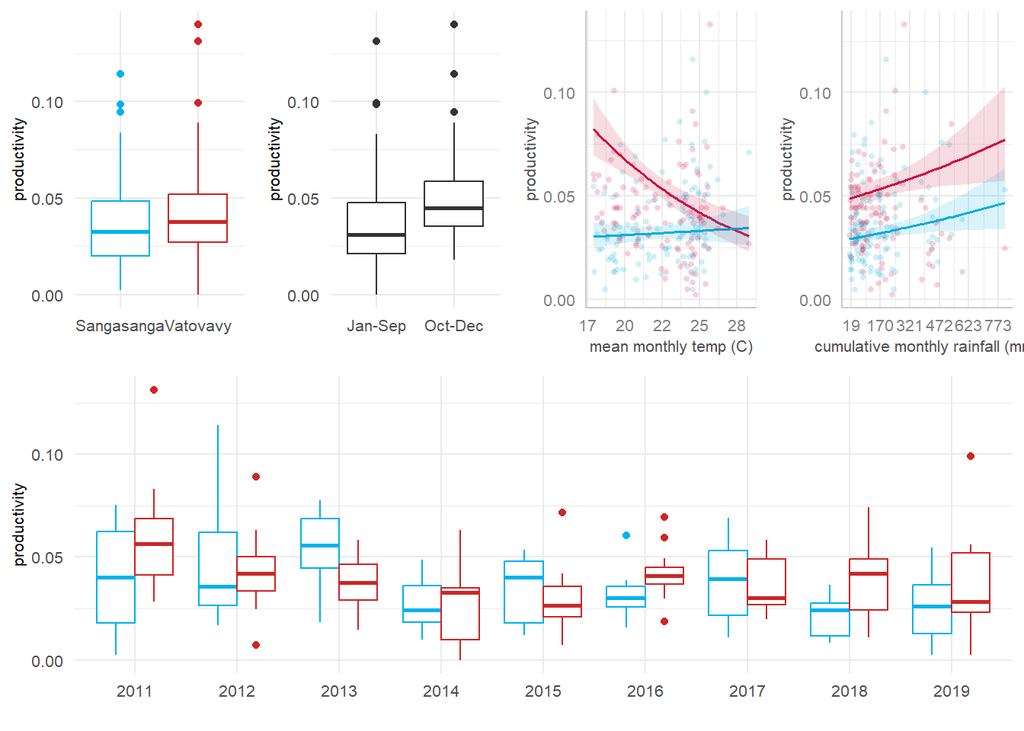

```r
# plot boxplot of flowering productivity within and outside of the dry-to-wet season transition
flptran <- ggplot(kphen_pop_fl,
                  aes(y = productivity,
                      x = as.factor(transition),
                      group = as.factor(transition))) +
                geom_boxplot(aes()) +
                theme_minimal() +
                ylab('productivity') +
                xlab('') +
                theme(legend.position = 'None',
                      text = element_text(size = 8),
                      axis.text = element_text(size = 8)) +
                scale_x_discrete(labels = c('Jan-Sep', 'Oct-Dec'))

# plot boxplot of flowering productivity between communities
flpc <- ggplot(kphen_pop_fl,
               aes(y = productivity,
                   x = dataset,
                   group = dataset)) +
              geom_boxplot(aes(color = dataset)) +
              theme_minimal() +
              ylab('productivity') +
              xlab('') +
              theme(legend.position = 'None',
                    text = element_text(size = 8),
                    axis.text = element_text(size = 8)) +
              scale_color_manual(values = c("sssw" = 'deepskyblue2', "vvsw" = 'firebrick3')) +
              scale_x_discrete(labels = c('Sangasanga','Vatovavy'))

# plot estimated relationship between temperature and flowering productivity
flpt <- plot(ggpredict(flp_best,
                       terms = c("temp[all]","dataset"),
                       type = 'fe'),
                       ci = T,
                       add.data =T,
                       colors = 'metro',
                       jitter = 0.0001,
                       show.legend= F,
                       show.title = F,
                       dot.size=1,
                       dot.alpha=0.2) +
              xlab('mean monthly temp (C)') +
              ylab('productivity') +
              theme(legend.position = 'None',
                    text = element_text(size = 8),
                    axis.text = element_text(size = 8)) +
              scale_x_continuous(labels = ~round(.*sd(kphen_pop_fl$temp) + mean(kphen_pop_fl$temp),0))

# plot estimated relationship between rain and flowering productivity
flpr <- plot(ggpredict(flp_best,
                       terms = c("rain[all]","dataset"),
                       type = 'fe'),
                       ci = T,
                       add.data =T,
                       colors = 'metro',
                       jitter = 0.0001,
                       show.legend= F,
                       show.title = F,
                       dot.size=1,
                       dot.alpha=0.2) +
                xlab('cumulative monthly rainfall (mm)') +
                ylab('productivity') +
                theme(legend.position = 'None',
                      text = element_text(size = 8),
                      axis.text = element_text(size = 8)) +
                scale_x_continuous(labels = ~round(.*sd(kphen_pop_fl$rain) + mean(kphen_pop_fl$rain),0))

# plot boxplot of flowering productivity across years
flpy <- ggplot(kphen_pop_fl %>% filter(year > 2010),
               aes(y = productivity,
                   x = as.factor(year),
                   color = dataset)) +
              geom_boxplot(position = "dodge") +
              theme_minimal() +
              ylab('productivity') +
              xlab('') +
              theme(legend.position = 'None',
                    text = element_text(size = 8),
                    axis.text = element_text(size = 8)) +
              scale_color_manual(values = c("sssw" = 'deepskyblue2', "vvsw" = 'firebrick3'))

# arrange plots and output
grid.arrange(arrangeGrob(flpc, flptran, flpt, flpr, ncol=4, nrow=1),
             arrangeGrob(flpy, ncol=1, nrow=1),
             ncol=1,
             nrow =2)
```

```r
# Combine flower phenology plots into a single figure and save
# arrange figure
fl_plots <- grid.arrange(arrangeGrob(flic, flitran,flir,flit, ncol=4, nrow=1),
                         arrangeGrob(fliy, ncol=1, nrow=1),
                         arrangeGrob(flspc, flsptran,flspr, ncol=3, nrow=1),
                         arrangeGrob(flspy, ncol=1, nrow=1),
                         arrangeGrob(flpc, flptran, flpr, flpt, ncol=4, nrow=1),
                         arrangeGrob(flpy, ncol=1, nrow=1),
                         ncol = 1,
                         nrow =6)
```

```r
# save figure
ggsave(file = 'Fig2.png',
       plot = fl_plots,
       width = 6.5,
       height = 9,
       units = 'in')
```

**GLM for fruiting individuals with community interactions**

```r
# using zero sum contrast on onset and years. Aliased: year 2019
mod1 <- glm(individuals~rain*dataset +rad*dataset + year*dataset,
            binomial('logit'),
            data = comm_fr_std,
            weights = n)

mod2 <- glm(individuals~rain*dataset +temp*dataset + year*dataset,
            binomial('logit'),
            data = comm_fr_std,
            weights = n)

mod3 <- glm(individuals~rain +rad*dataset + year*dataset,
            binomial('logit'),
            data = comm_fr_std,
            weights = n)

mod4 <- glm(individuals~rain +temp*dataset + year*dataset,
            binomial('logit'),
            data = comm_fr_std,
            weights = n)

# generate aic and extract information from best model
ikfri <- aic_best(list(mod1,mod2,mod3,mod4), 'fruit','individual')

# assign best model object
fri_best <- ikfri[[3]]

# print aic table
ikfri[[1]]
```

```
##   Modnames  K     AICc Delta_AICc   ModelLik     AICcWt        LL    Cum.Wt
## 4     Mod4 21 1506.457   0.000000 1.00000000 0.60264823 -729.8470 0.6026482
## 2     Mod2 22 1508.728   2.270984 0.32126410 0.19360924 -729.7422 0.7962575
## 1     Mod1 22 1509.066   2.608594 0.27136327 0.16353660 -729.9110 0.9597941
## 3     Mod3 21 1511.872   5.414638 0.06671543 0.04020593 -732.5544 1.0000000
##    pseudor2  pseudoR2
## 4 0.4747365 0.2308902
## 2 0.4751022 0.2310681
## 1 0.4690096 0.2281049
## 3 0.4748751 0.2309576
```

```r
# print summary of best model
summary(fri_best)
```

```
##
## Call:
## glm(formula = individuals ~ rain + temp * dataset + year * dataset,
##     family = binomial("logit"), data = comm_fr_std, weights = n)
##
## Deviance Residuals:
##     Min       1Q   Median       3Q      Max
## -3.6967  -0.9865  -0.0057   0.7688   5.8644
##
## Coefficients:
##                   Estimate Std. Error z value Pr(>|z|)
## (Intercept)       -1.48762    0.02676 -55.594  < 2e-16 ***
## rain               0.08980    0.02020   4.445 8.81e-06 ***
## temp              -0.06216    0.02770  -2.244  0.02484 *
## datasetsssw        0.17193    0.03569   4.817 1.46e-06 ***
## year1              0.08694    0.07162   1.214  0.22483
## year2             -0.57302    0.08736  -6.560 5.40e-11 ***
## year3             -0.21263    0.07768  -2.737  0.00619 **
## year4             -0.89423    0.09877  -9.054  < 2e-16 ***
## year5              0.10345    0.07102   1.457  0.14522
## year6              0.48626    0.06569   7.402 1.34e-13 ***
## year7              0.32916    0.06766   4.865 1.14e-06 ***
## year8              0.16573    0.06995   2.369  0.01783 *
## temp:datasetsssw   0.15871    0.03471   4.572 4.82e-06 ***
## datasetsssw:year1 -0.12012    0.09771  -1.229  0.21890
## datasetsssw:year2  0.12961    0.11508   1.126  0.26005
## datasetsssw:year3  0.15488    0.10284   1.506  0.13206
## datasetsssw:year4  0.94325    0.11846   7.963 1.68e-15 ***
## datasetsssw:year5 -0.01458    0.09564  -0.152  0.87885
## datasetsssw:year6 -0.51875    0.09368  -5.537 3.07e-08 ***
## datasetsssw:year7  0.18845    0.09001   2.094  0.03628 *
## datasetsssw:year8 -0.30424    0.09792  -3.107  0.00189 **
## ---
## Signif. codes:  0 '***' 0.001 '**' 0.01 '*' 0.05 '.' 0.1 ' ' 1
##
## (Dispersion parameter for binomial family taken to be 1)
##
##     Null deviance: 923.13  on 215  degrees of freedom
## Residual deviance: 484.76  on 195  degrees of freedom
## AIC: 1501.7
##
## Number of Fisher Scoring iterations: 4
```

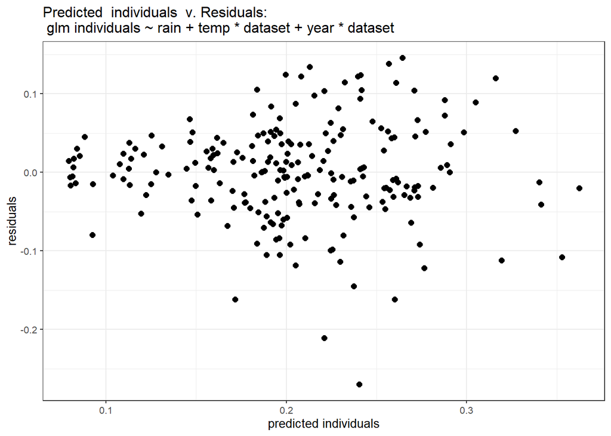

```r
# plot residuals
residual_plot(fri_best, comm_fr_std, 'individuals')
```

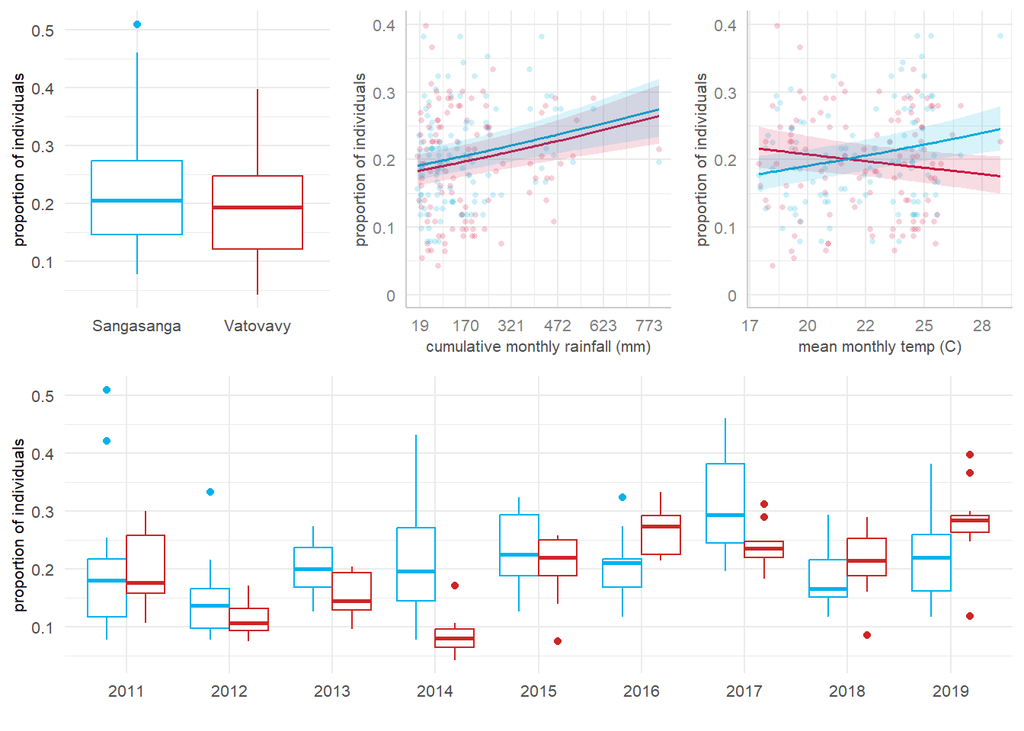

```r
# plot boxplot of prop. fruiting individuals between communities
fric <- ggplot(kphen_pop_fr,
               aes(y = individuals,
                   x = dataset,
                   group = dataset)) +
          geom_boxplot(aes(color = dataset)) +
          theme_minimal() +
          ylab('proportion of individuals') +
          xlab('') +
          theme(legend.position = 'None',
                text = element_text(size = 8),
                axis.text = element_text(size = 8)) +
          scale_color_manual(values = c("sssw" = 'deepskyblue2', "vvsw" = 'firebrick3')) +
          scale_x_discrete(labels = c('Sangasanga','Vatovavy'))

# plot estimated relaitonship between rain and prop. of individuals fruiting
frir <- plot(ggpredict(fri_best,
                       terms = c("rain[all]","dataset"),
                       type = 'fe'),
                       ci = T,
                       add.data =T,
                       colors = 'metro',
                       jitter = 0.0001,
                       show.legend= F,
                       show.title = F,
                       dot.size=1,
                       dot.alpha=0.2) +
              xlab('cumulative monthly rainfall (mm)') +
              ylab('proportion of individuals') +
              theme(legend.position = 'None',
                    text = element_text(size = 8),
                    axis.text = element_text(size = 8)) +
              scale_x_continuous(labels = ~round(.*sd(kphen_pop_fr$rain) + mean(kphen_pop_fr$rain),0)) +
              scale_y_continuous(limits = c(0, 0.4),
                                 labels = c(0,0.1,0.2,0.3,0.4))

# plot estimated relaitonship between temperature and prop. of individuals fruiting
frit <- plot(ggpredict(fri_best,
                       terms = c("temp[all]","dataset"),
                       type = 'fe'),
                       ci = T,
                       add.data =T,
                       colors = 'metro',
                       jitter = 0.0001,
                       show.legend= F,
                       show.title = F,
                       dot.size=1,
                       dot.alpha=0.2) +
            xlab('mean monthly temp (C)') +
            ylab('proportion of individuals') +
            theme(legend.position = 'None',
                  text = element_text(size = 8),
                  axis.text = element_text(size = 8)) +
            scale_x_continuous(labels = ~round(.*sd(kphen_pop_fr$temp) + mean(kphen_pop_fr$temp),0)) +
            scale_y_continuous(limits = c(0, 0.4),
                               labels = c(0,0.1,0.2,0.3,0.4))

# plot boxplot of prop. fruiting individuals across years
friy <- ggplot(kphen_pop_fr %>% filter(year > 2010),
               aes(y = individuals,
                   x = as.factor(year),
                   color = dataset)) +
              geom_boxplot(position = "dodge") +
              theme_minimal() +
              ylab('proportion of individuals') +
              xlab('') +
              theme(legend.position = 'None',
                    text = element_text(size = 8),
                    axis.text = element_text(size = 8)) +
              scale_color_manual(values = c("sssw" = 'deepskyblue2', "vvsw" = 'firebrick3'))

# arrange plots and output
grid.arrange(arrangeGrob(fric, frir,frit, ncol=3, nrow=1),
             arrangeGrob(friy, ncol=1, nrow=1),
             ncol = 1,
             nrow = 2)
```

**GLM for fruit taxa with community interactions**

```r
# using zero sum contrast on onset and years. Aliased: year 2019
mod1 <- glm(sprich~rain*dataset +rad*dataset + year*dataset,
            binomial('logit'),
            data = comm_fr_std,
            weights = ns)

mod2 <- glm(sprich~ rain*dataset +temp*dataset + year*dataset,
            binomial('logit'),
            data = comm_fr_std,
            weights = ns)

mod3 <- glm(sprich~ rain + year*dataset,
            binomial('logit'),
            data = comm_fr_std,
            weights = ns)

mod4 <- glm(sprich~ rain + year + dataset,
            binomial('logit'),
            data = comm_fr_std,
            weights = ns)

mod5 <- glm(sprich~ rain + year,
            binomial('logit'),
            data = comm_fr_std,
            weights = ns)

# generate aic and extract information from best model
ikfrsp <- aic_best(list(mod1,mod2,mod3,mod4,mod5), 'fruit','species')

# assign best model object
frsp_best <- ikfrsp[[3]]

# print aic table
ikfrsp[[1]]
```

```
##   Modnames  K     AICc Delta_AICc   ModelLik     AICcWt        LL    Cum.Wt
## 3     Mod3 19 1021.063   0.000000 1.00000000 0.89347059 -489.5925 0.8934706
## 2     Mod2 22 1027.413   6.350287 0.04178812 0.03733645 -489.0847 0.9308070
## 5     Mod5 10 1027.796   6.733177 0.03450716 0.03083113 -503.3613 0.9616382
## 1     Mod1 22 1028.091   7.028116 0.02977585 0.02660384 -489.4236 0.9882420
## 4     Mod4 11 1029.724   8.661162 0.01315990 0.01175798 -503.2148 1.0000000
##    pseudor2   pseudoR2
## 3 0.4130955 0.11420144
## 2 0.4153143 0.11481484
## 5 0.4119895 0.11389570
## 1 0.3228071 0.08924096
## 4 0.3218481 0.08897585
```

```r
# print summary of best model
summary(frsp_best)
```

```
##
## Call:
## glm(formula = sprich ~ rain + year * dataset, family = binomial("logit"),
##     data = comm_fr_std, weights = ns)
##
## Deviance Residuals:
##      Min        1Q    Median        3Q       Max
## -2.88321  -0.69506  -0.08233   0.50376   2.97066
##
## Coefficients:
##                   Estimate Std. Error z value Pr(>|z|)
## (Intercept)       -1.21066    0.03776 -32.061  < 2e-16 ***
## rain               0.13609    0.02559   5.318 1.05e-07 ***
## year1              0.26363    0.09949   2.650  0.00805 **
## year2             -0.09533    0.10753  -0.887  0.37535
## year3              0.17713    0.10128   1.749  0.08031 .
## year4             -0.73162    0.13058  -5.603 2.11e-08 ***
## year5             -0.10632    0.10747  -0.989  0.32251
## year6              0.19566    0.10162   1.925  0.05418 .
## year7              0.16037    0.10167   1.577  0.11470
## year8             -0.07271    0.10691  -0.680  0.49643
## datasetsssw        0.03364    0.05332   0.631  0.52811
## year1:datasetsssw -0.26544    0.14509  -1.829  0.06733 .
## year2:datasetsssw -0.34836    0.16008  -2.176  0.02954 *
## year3:datasetsssw -0.15178    0.14593  -1.040  0.29829
## year4:datasetsssw  0.50179    0.17211   2.916  0.00355 **
## year5:datasetsssw  0.21041    0.14831   1.419  0.15596
## year6:datasetsssw -0.33522    0.14965  -2.240  0.02509 *
## year7:datasetsssw  0.33651    0.14010   2.402  0.01631 *
## year8:datasetsssw  0.02654    0.15096   0.176  0.86046
## ---
## Signif. codes:  0 '***' 0.001 '**' 0.01 '*' 0.05 '.' 0.1 ' ' 1
##
## (Dispersion parameter for binomial family taken to be 1)
##
##     Null deviance: 305.49  on 215  degrees of freedom
## Residual deviance: 179.63  on 197  degrees of freedom
## AIC: 1017.2
##
## Number of Fisher Scoring iterations: 4
```

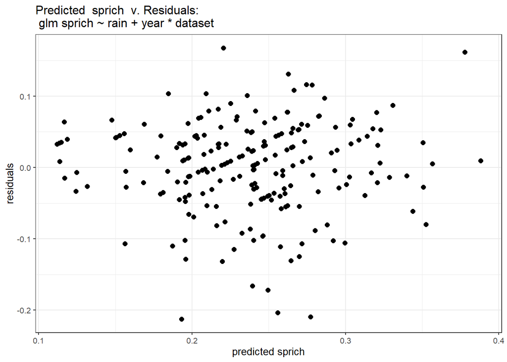

```r
# plot residuals
residual_plot(frsp_best, comm_fr_std, 'sprich')
```

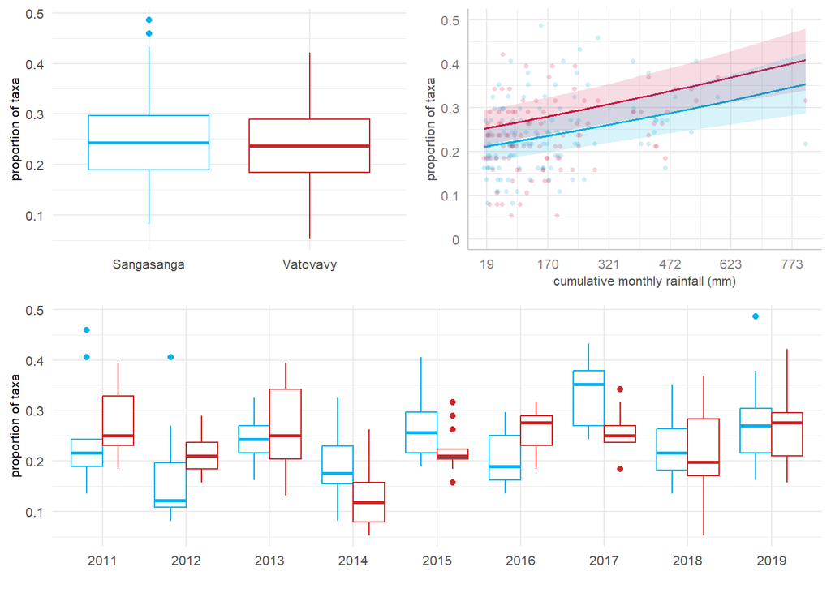

```r
# plot boxplot of prop. fruiting taxa between communities
frspc <- ggplot(kphen_pop_fr,
                aes(y = sprich,
                    x = dataset,
                    group = dataset)) +
            geom_boxplot(aes(color = dataset)) +
            theme_minimal() +
            ylab('proportion of taxa') +
            xlab('') +
            theme(legend.position = 'None',
                  text = element_text(size = 8),
                  axis.text = element_text(size = 8)) +
            scale_color_manual(values = c("sssw" = 'deepskyblue2', "vvsw" = 'firebrick3')) +
            scale_x_discrete(labels = c('Sangasanga','Vatovavy'))

# plot estimated relaitonship between rain and prop. of taxa fruiting
frspr <- plot(ggpredict(frsp_best,
                        terms = c("rain[all]","dataset"),
                        type = 'fe'),
                        ci = T,
                        add.data =T,
                        colors = 'metro',
                        jitter = 0.0001,
                        show.legend= F,
                        show.title = F,
                        dot.size=1,
                        dot.alpha=0.2) +
              xlab('cumulative monthly rainfall (mm)') +
              ylab('proportion of taxa') +
              theme(legend.position = 'None',
                    text = element_text(size = 8),
                    axis.text = element_text(size = 8)) +
              scale_x_continuous(labels = ~round(.*sd(kphen_pop_fr$rain) + mean(kphen_pop_fr$rain),0)) +
              scale_y_continuous(limits = c(0, 0.5),
                                 labels = c(0,0.1,0.2,0.3,0.4,0.5))

# plot boxplot of prop. fruiting taxa across years
frspy <- ggplot(kphen_pop_fr %>% filter(year > 2010),
                aes(y = sprich,
                    x = as.factor(year),
                    color = dataset)) +
                geom_boxplot(position = "dodge") +
                theme_minimal() +
                ylab('proportion of taxa') +
                xlab('') +
                theme(legend.position = 'None',
                      text = element_text(size = 8),
                      axis.text = element_text(size = 8)) +
                scale_color_manual(values = c("sssw" = 'deepskyblue2', "vvsw" = 'firebrick3'))

# arrange plots and output
grid.arrange(arrangeGrob(frspc, frspr, ncol=2, nrow=1),
             arrangeGrob(frspy, ncol=1, nrow=1),
             ncol = 1,
             nrow =2)
```

**GLM for fruit productivity with community interactions (beta)**

```r
mod1 <- betareg(productivity~rain*dataset +rad*dataset + year*dataset,
             comm_fr_std,
             link = 'logit')

mod2 <- betareg(productivity~rain*dataset +temp*dataset + year*dataset,
             comm_fr_std,
             link = 'logit')

mod3 <- betareg(productivity~rain +rad + year*dataset,
             comm_fr_std,
             link = 'logit')

mod4 <- betareg(productivity~rain +temp + year*dataset,
             comm_fr_std,
             link = 'logit')

mod5 <- betareg(productivity~rain + year*dataset,
             comm_fr_std,
             link = 'logit')

mod6 <- betareg(productivity~ year*dataset,
             comm_fr_std,
             link = 'logit')

# generate aic and extract information from best model
ikfrp <- aic_best(list(mod1,mod2,mod3,mod4,mod5,mod6), 'fruit','productivity',T)

# assign best model object
frp_best <- ikfrp[[3]]

# print aic table
ikfrp[[1]]
```

```
##   Modnames  K      AICc Delta_AICc   ModelLik     AICcWt       LL    Cum.Wt
## 5     Mod5 20 -1042.358  0.0000000 1.00000000 0.40660607 543.3328 0.4066061
## 3     Mod3 21 -1041.572  0.7858506 0.67507919 0.27449130 544.1674 0.6810974
## 4     Mod4 21 -1041.017  1.3412394 0.51139158 0.20793492 543.8897 0.8890323
## 1     Mod1 23 -1038.886  3.4723191 0.17619577 0.07164227 545.3178 0.9606746
## 2     Mod2 23 -1036.801  5.5571982 0.06212548 0.02526060 544.2753 0.9859352
## 6     Mod6 19 -1035.629  6.7283336 0.03459083 0.01406484 538.7535 1.0000000
##   pseudor2  pseudoR2
## 5       NA 0.5550650
## 3       NA 0.5540901
## 4       NA 0.5551247
## 1       NA 0.5547262
## 2       NA 0.5549834
## 6       NA 0.5234731
```

```r
# print summary of best model
summary(frp_best)
```

```
##
## Call:
## betareg(formula = productivity ~ rain + year * dataset, data = comm_fr_std,
##     link = "logit")
##
## Standardized weighted residuals 2:
##     Min      1Q  Median      3Q     Max
## -3.7402 -0.6504  0.1241  0.7634  2.5924
##
## Coefficients (mean model with logit link):
##                   Estimate Std. Error z value Pr(>|z|)
## (Intercept)       -2.64637    0.03322 -79.658  < 2e-16 ***
## rain               0.07089    0.02201   3.221 0.001279 **
## year1             -0.17294    0.09544  -1.812 0.069975 .
## year2             -0.74050    0.11815  -6.267 3.68e-10 ***
## year3             -0.20469    0.09660  -2.119 0.034099 *
## year4             -0.65567    0.11473  -5.715 1.10e-08 ***
## year5              0.09215    0.08657   1.065 0.287098
## year6              0.47459    0.07714   6.153 7.62e-10 ***
## year7              0.40839    0.07829   5.216 1.82e-07 ***
## year8              0.22451    0.08294   2.707 0.006789 **
## datasetsssw       -0.08941    0.04654  -1.921 0.054726 .
## year1:datasetsssw  0.37299    0.12873   2.897 0.003762 **
## year2:datasetsssw  0.36980    0.15882   2.328 0.019889 *
## year3:datasetsssw  0.43565    0.12902   3.377 0.000734 ***
## year4:datasetsssw  0.68787    0.14696   4.681 2.86e-06 ***
## year5:datasetsssw -0.18566    0.12844  -1.445 0.148333
## year6:datasetsssw -0.46157    0.12056  -3.828 0.000129 ***
## year7:datasetsssw -0.08229    0.11398  -0.722 0.470302
## year8:datasetsssw -0.52091    0.13243  -3.934 8.37e-05 ***
##
## Phi coefficients (precision model with identity link):
##       Estimate Std. Error z value Pr(>|z|)
## (phi)   142.74      13.81   10.34   <2e-16 ***
## ---
## Signif. codes:  0 '***' 0.001 '**' 0.01 '*' 0.05 '.' 0.1 ' ' 1
##
## Type of estimator: ML (maximum likelihood)
## Log-likelihood: 543.3 on 20 Df
## Pseudo R-squared: 0.555
## Number of iterations: 35 (BFGS) + 2 (Fisher scoring)
```

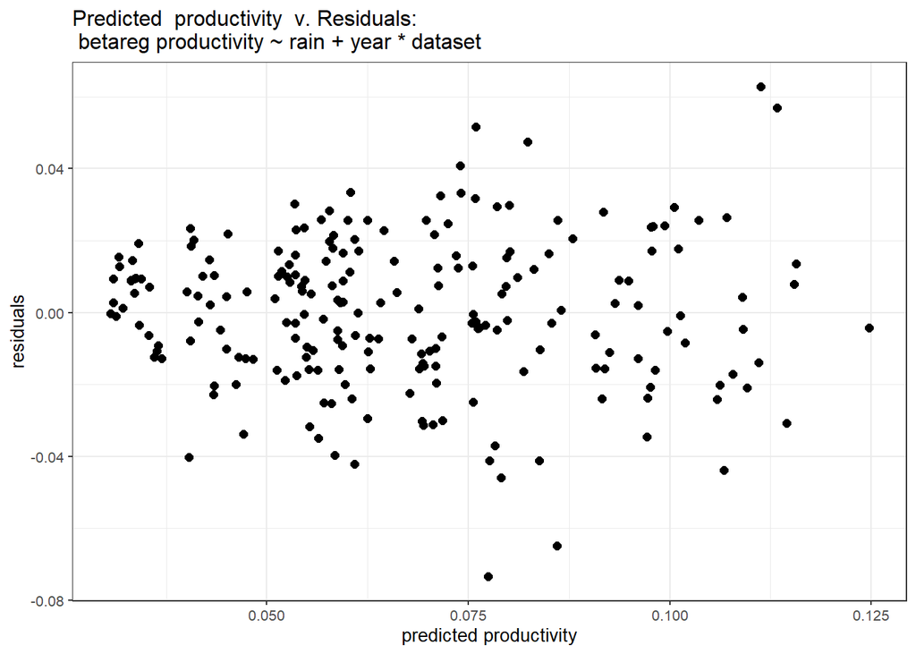

```r
# plot residuals
residual_plot(frp_best, comm_fr_std, 'productivity')
```

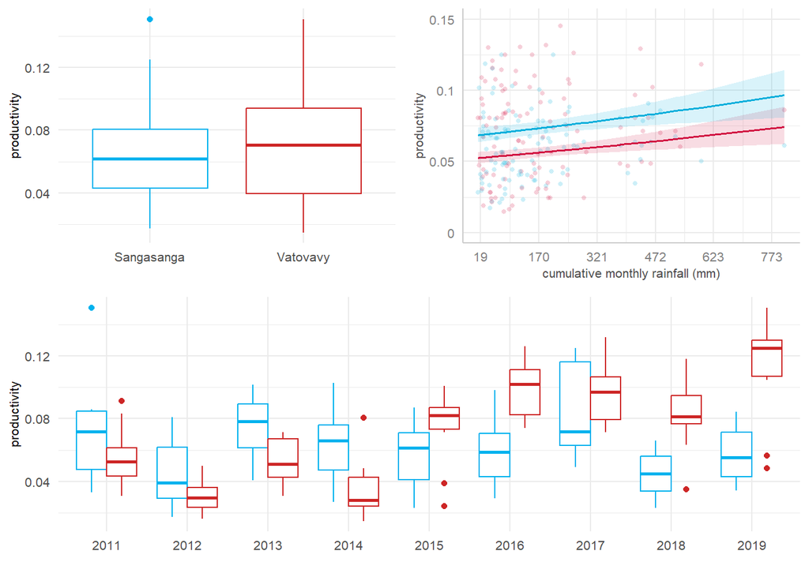

```r
# plot boxplot of fruiting productivity between communities
frpc <- ggplot(kphen_pop_fr,
               aes(y = productivity,
                   x = dataset,
                   group = dataset)) +
            geom_boxplot(aes(color = dataset)) +
            theme_minimal() +
            ylab('productivity') +
            xlab('') +
            theme(legend.position = 'None',
                  text = element_text(size = 8),
                  axis.text = element_text(size = 8)) +
            scale_color_manual(values = c("sssw" = 'deepskyblue2', "vvsw" = 'firebrick3')) +
            scale_x_discrete(labels = c('Sangasanga','Vatovavy'))

# plot estimated relationship between rain and fruiting productivity
frpr <- plot(ggpredict(frp_best,
                       terms = c("rain[all]","dataset"),
                       type = 'fe'),
                       ci = T,
                       add.data =T,
                       colors = 'metro',
                       jitter = 0.0001,
                       show.legend= F,
                       show.title = F,
                       dot.size=1,
                       dot.alpha=0.2) +
              xlab('cumulative monthly rainfall (mm)') +
              ylab('productivity') +
              theme(legend.position = 'None',
                    text = element_text(size = 8),
                    axis.text = element_text(size = 8)) +
              scale_x_continuous(labels = ~round(.*sd(kphen_pop_fr$rain) + mean(kphen_pop_fr$rain),0)) +
              scale_y_continuous(limits = c(0, 0.15),
                                 labels = c(0,0.05,0.1,0.15))

# plot boxplot of fruiting productivity across years
frpy <- ggplot(kphen_pop_fr %>% filter(year > 2010),
               aes(y = productivity,
                   x = as.factor(year),
                   color = dataset)) +
            geom_boxplot(position = "dodge") +
            theme_minimal() +
            ylab('productivity') +
            xlab('') +
            theme(legend.position = 'None',
                  text = element_text(size = 8),
                  axis.text = element_text(size = 8)) +
            scale_color_manual(values = c("sssw" = 'deepskyblue2', "vvsw" = 'firebrick3'))

# arrange plots and output
grid.arrange(arrangeGrob(frpc, frpr, ncol=2, nrow=1),
         arrangeGrob(frpy, ncol=1, nrow=1),
         ncol = 1,
         nrow = 2)
```

```r
# Combine fruit phenology plots into a single figure and save
fr_plots <- grid.arrange(arrangeGrob(fric, frir,frit, ncol=3, nrow=1),
                         arrangeGrob(friy, ncol=1, nrow=1),
                         arrangeGrob(frspc, frspr, ncol=2, nrow=1),
                         arrangeGrob(frspy, ncol=1, nrow=1),
                         arrangeGrob(frpc, frpr, ncol=2, nrow=1),
                         arrangeGrob(frpy, ncol=1, nrow=1),
                         ncol = 1,
                         nrow =6)
```

```r
# save figure
ggsave(file = 'Fig3.png',plot = fr_plots,
      width = 6.5, height = 9, units = 'in')
```